# LME Analysis of NUCs

Antoin Rodgers

18.05.2022

### L targets

#### Analysis of L timing

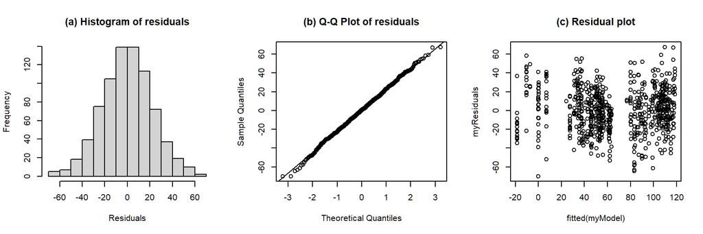

```
##
## Formula:
## l_t ~ foot_syls + pre_syls + fin_phon + nuc_new_word + gender +, (1 | speaker) + (1 | nuc_str_syl)
##
## Linear mixed model fit by REML. t-tests use Satterthwaite's method [
## lmerModLmerTest]
## Formula: l_t_equation
##    Data: nuc_l_t_data.trimmed
## Control:
## lmerControl(optimizer = optimizer, calc.derivs = F, optCtrl = list(method = "nlminb",
##     starttests = F, kkt = F))
##
## REML criterion at convergence: 7076.9
##
## Scaled residuals:
##      Min       1Q   Median       3Q      Max
## -3.07196 -0.66993  0.01925  0.63383  2.95894
##
## Random effects:
##  Groups      Name        Variance Std.Dev.
##  speaker     (Intercept) 132.8    11.52
##  nuc_str_syl (Intercept) 533.0    23.09
##  Residual                517.6    22.75
## Number of obs: 780, groups:  speaker, 11; nuc_str_syl, 3
##
## Fixed effects:
##                  Estimate Std. Error       df t value Pr(>|t|)
## (Intercept)       92.2265    15.1578   3.2340   6.084  0.00715 **
## foot_syls2        -0.4425     4.2340 759.4160  -0.105  0.91678
## foot_syls3         0.9313     3.3107 759.2965   0.281  0.77856
## foot_syls4        -1.6680     5.3078 760.9706  -0.314  0.75342
## pre_syls1         -4.8925     3.3465 759.9802  -1.462  0.14416
## pre_syls2         -1.4337     5.3172 761.2515  -0.270  0.78751
## pre_syls3        -11.6185     5.4877 761.6638  -2.117  0.03457 *
## fin_phonL%         3.3729     5.1187 767.0586   0.659  0.51013
## nuc_new_wordTRUE  -3.3704     3.2429 760.6453  -1.039  0.29897
## genderM          -54.9250     7.1692   8.9565  -7.661 3.21e-05 ***
## ---
## Signif. codes:  0 '***' 0.001 '**' 0.01 '*' 0.05 '.' 0.1 ' ' 1
##
## Correlation of Fixed Effects:
##             (Intr) ft_sy2 ft_sy3 ft_sy4 pr_sy1 pr_sy2 pr_sy3 fn_pL% n__TRU
## foot_syls2  -0.036
## foot_syls3  -0.110  0.322
## foot_syls4  -0.207  0.366  0.261
## pre_syls1   -0.104 -0.422  0.087 -0.334
## pre_syls2   -0.176 -0.692  0.056 -0.023  0.630
## pre_syls3   -0.189 -0.672  0.055  0.009  0.612  0.822
## fin_phonL%  -0.010  0.072 -0.048 -0.012 -0.031 -0.028 -0.043
## nc_nw_wTRUE -0.293 -0.002  0.002  0.611  0.002  0.308  0.351 -0.028
## genderM     -0.218 -0.003  0.002  0.002  0.004  0.005  0.009  0.004  0.007
```

ANOVA of model: l_t ~ foot_syls + pre_syls + fin_phon + nuc_new_word + gender +, (1 | speaker) + (1 | nuc_str_syl)

| term | sumsq | meansq | NumDF | DenDF | F value | p.value | p.adj (BH) | signif. |
| --- | --- | --- | --- | --- | --- | --- | --- | --- |
| foot_syls | 128.29 | 42.76 | 3 | 760.16 | 0.08 | .969 | .969 |  |
| pre_syls | 6264 | 2088 | 3 | 757.92 | 4.03 | .007 | .014 | *p* < .05 |
| fin_phon | 224.72 | 224.72 | 1 | 767.06 | 0.43 | .51 | .565 |  |
| nuc_new_word | 559.08 | 559.08 | 1 | 760.64 | 1.08 | .299 | .366 |  |
| gender | 30378 | 30378 | 1 | 8.96 | 58.7 | < .001 | < .001 | *p* < .05 |

Omega<sup>2</sup> (partial) for l_t.

| Parameter | ω<sup>2</sup><sub>*p*</sub> | 95% CI |
| --- | --- | --- |
| foot_syls | 0 | [0, 0] |
| pre_syls | .01 | [0, .03] |
| fin_phon | 0 | [0, 0] |
| nuc_new_word | 0 | [0, .01] |
| gender | .84 | [.52, .92] |

Conditional and marginal R<sup>2</sup>

| marginal R<sup>2</sup> | conditional R<sup>2</sup> |
| --- | --- |
| .37 | .71 |

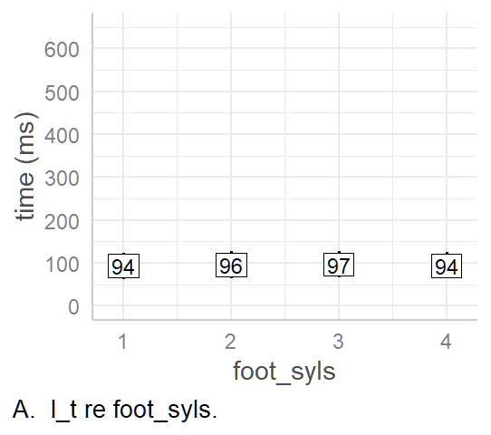

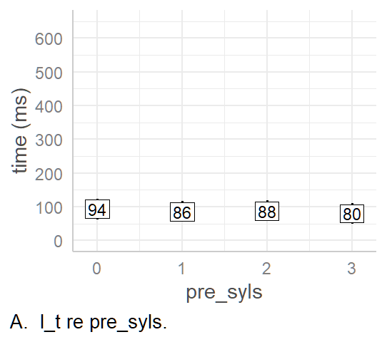

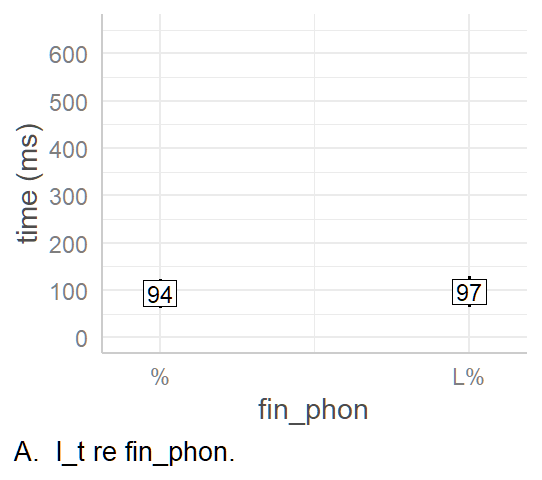

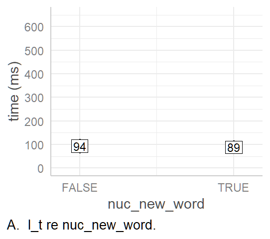

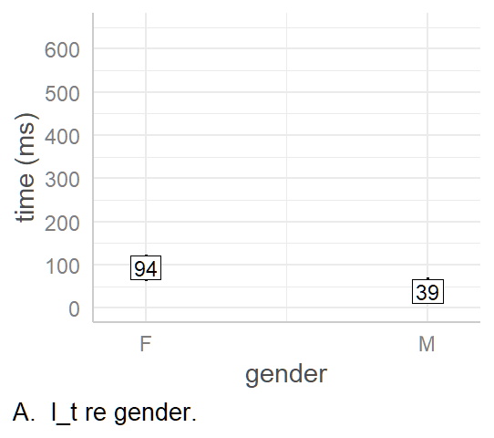

Predicted values of l_t

| foot_syls | predicted | conf.low | conf.high | std.error |
| --- | --- | --- | --- | --- |
| 1 | 93.6 | 62.96 | 124.24 | 15.61 |
| 2 | 95.69 | 64.15 | 127.23 | 16.07 |
| 3 | 96.52 | 65.89 | 127.15 | 15.6 |
| 4 | 94.23 | 63.94 | 124.52 | 15.43 |

Predicted values of l_t

| pre_syls | predicted | conf.low | conf.high | std.error |
| --- | --- | --- | --- | --- |
| 0 | 93.6 | 62.96 | 124.24 | 15.61 |
| 1 | 85.8 | 55.14 | 116.45 | 15.61 |
| 2 | 87.55 | 56.93 | 118.17 | 15.6 |
| 3 | 80.12 | 49.61 | 110.64 | 15.54 |

Predicted values of l_t

| fin_phon | predicted | conf.low | conf.high | std.error |
| --- | --- | --- | --- | --- |
| % | 93.6 | 62.96 | 124.24 | 15.61 |
| L% | 97.32 | 65 | 129.64 | 16.47 |

Predicted values of l_t

| nuc_new_word | predicted | conf.low | conf.high | std.error |
| --- | --- | --- | --- | --- |
| FALSE | 93.6 | 62.96 | 124.24 | 15.61 |
| TRUE | 88.62 | 59.26 | 117.97 | 14.95 |

Predicted values of l_t

| gender | predicted | conf.low | conf.high | std.error |
| --- | --- | --- | --- | --- |
| F | 93.6 | 62.96 | 124.24 | 15.61 |
| M | 39.46 | 8.53 | 70.4 | 15.76 |

l_t ~ foot_syls + pre_syls + fin_phon + nuc_new_word + gender + (1 | speaker) + (1 | nuc_str_syl)

b1: l_t ~ foot_syls + pre_syls + fin_phon + nuc_new_word + gender +, (1 | speaker) + (1 | nuc_str_syl)

| intercept | slope | estimate | conf.low | conf.high | std.error | t.value | df | p.value |
| --- | --- | --- | --- | --- | --- | --- | --- | --- |
| foot_syls1 | foot_syls2 | 2 | -7 | 11 | 4.4 | 0.47 | 767.35 | .635 |
| foot_syls1 | foot_syls3 | 3 | -4 | 10 | 3.48 | 0.84 | 767.36 | .402 |
| foot_syls1 | foot_syls4 | 1 | -10 | 12 | 5.55 | 0.11 | 768.93 | .91 |
| foot_syls2 | foot_syls3 | 1 | -8 | 10 | 4.68 | 0.18 | 767.81 | .859 |
| foot_syls2 | foot_syls4 | -1 | -13 | 10 | 5.72 | -0.26 | 768.8 | .799 |
| foot_syls3 | foot_syls4 | -2 | -14 | 9 | 5.76 | -0.4 | 769.05 | .691 |
| pre_syls0 | pre_syls1 | -8 | -15 | -1 | 3.5 | -2.23 | 767.76 | .026 |
| pre_syls0 | pre_syls2 | -6 | -17 | 5 | 5.56 | -1.09 | 769.22 | .277 |
| pre_syls0 | pre_syls3 | -14 | -25 | -2 | 5.75 | -2.34 | 769.54 | .019 |
| pre_syls1 | pre_syls2 | 2 | -7 | 10 | 4.31 | 0.41 | 768.91 | .685 |
| pre_syls1 | pre_syls3 | -6 | -15 | 3 | 4.56 | -1.24 | 767.98 | .214 |
| pre_syls2 | pre_syls3 | -7 | -14 | -1 | 3.38 | -2.2 | 751.77 | .028 |
| intercept | fin_phonL% | 4 | -7 | 14 | 5.41 | 0.69 | 775.05 | .492 |
| intercept | nuc_new_wordT | -5 | -12 | 2 | 3.4 | -1.47 | 768.4 | .143 |
| intercept | genderM | -54 | -71 | -37 | 7.61 | -7.12 | 8.97 | < .001 |

#### Analysis of L F0

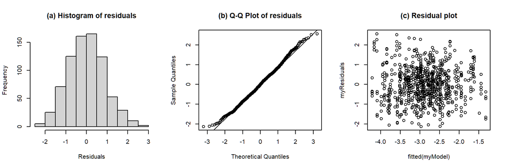

```
##
## Formula:
## l_f0 ~ foot_syls + pre_syls + fin_phon + nuc_new_word + gender +, (1 | speaker) + (1 | nuc_str_syl)
##
## Linear mixed model fit by REML. t-tests use Satterthwaite's method [
## lmerModLmerTest]
## Formula: l_f0_equation
##    Data: nuc_l_f0.trimmed
## Control:
## lmerControl(optimizer = optimizer, calc.derivs = F, optCtrl = list(method = "nlminb",
##     starttests = F, kkt = F))
##
## REML criterion at convergence: 2055.7
##
## Scaled residuals:
##      Min       1Q   Median       3Q      Max
## -2.39360 -0.67453 -0.01464  0.63447  2.87877
##
## Random effects:
##  Groups      Name        Variance Std.Dev.
##  speaker     (Intercept) 0.38301  0.6189
##  nuc_str_syl (Intercept) 0.01128  0.1062
##  Residual                0.79008  0.8889
## Number of obs: 770, groups:  speaker, 11; nuc_str_syl, 3
##
## Fixed effects:
##                   Estimate Std. Error        df t value Pr(>|t|)
## (Intercept)       -3.20444    0.32159  17.41030  -9.964 1.30e-08 ***
## foot_syls2         0.50679    0.16479 749.67597   3.075  0.00218 **
## foot_syls3         0.46211    0.12919 749.70143   3.577  0.00037 ***
## foot_syls4         0.80844    0.20004 279.87196   4.041 6.87e-05 ***
## pre_syls1          0.12279    0.13027 749.90887   0.943  0.34622
## pre_syls2         -0.27655    0.19945 260.78119  -1.387  0.16676
## pre_syls3         -0.19659    0.20298 138.42171  -0.969  0.33447
## fin_phonL%        -0.08214    0.20027 755.56247  -0.410  0.68180
## nuc_new_wordTRUE   0.18113    0.11522  44.15525   1.572  0.12310
## genderM           -0.25456    0.38029   8.98291  -0.669  0.52008
## ---
## Signif. codes:  0 '***' 0.001 '**' 0.01 '*' 0.05 '.' 0.1 ' ' 1
##
## Correlation of Fixed Effects:
##             (Intr) ft_sy2 ft_sy3 ft_sy4 pr_sy1 pr_sy2 pr_sy3 fn_pL% n__TRU
## foot_syls2  -0.064
## foot_syls3  -0.202  0.319
## foot_syls4  -0.312  0.374  0.267
## pre_syls1   -0.195 -0.418  0.093 -0.341
## pre_syls2   -0.265 -0.719  0.062 -0.080  0.654
## pre_syls3   -0.282 -0.708  0.063 -0.060  0.644  0.865
## fin_phonL%  -0.015  0.072 -0.049 -0.016 -0.031 -0.026 -0.054
## nc_nw_wTRUE -0.451 -0.003  0.003  0.576  0.002  0.250  0.278 -0.035
## genderM     -0.539 -0.003  0.000 -0.003  0.006  0.004  0.005  0.003  0.002
```

ANOVA of model: l_f0 ~ foot_syls + pre_syls + fin_phon + nuc_new_word + gender +, (1 | speaker) + (1 | nuc_str_syl)

| term | sumsq | meansq | NumDF | DenDF | F value | p.value | p.adj (BH) | signif. |
| --- | --- | --- | --- | --- | --- | --- | --- | --- |
| foot_syls | 19.14 | 6.38 | 3 | 543.12 | 8.07 | < .001 | < .001 | *p* < .05 |
| pre_syls | 6.24 | 2.08 | 3 | 40.99 | 2.63 | .063 | .092 |  |
| fin_phon | 0.13 | 0.13 | 1 | 755.56 | 0.17 | .682 | .72 |  |
| nuc_new_word | 1.95 | 1.95 | 1 | 44.16 | 2.47 | .123 | .167 |  |
| gender | 0.35 | 0.35 | 1 | 8.98 | 0.45 | .52 | .565 |  |

Omega<sup>2</sup> (partial) for l_f0.

| Parameter | ω<sup>2</sup><sub>*p*</sub> | 95% CI |
| --- | --- | --- |
| foot_syls | .04 | [.01, .07] |
| pre_syls | .1 | [0, .26] |
| fin_phon | 0 | [0, 0] |
| nuc_new_word | .03 | [0, .18] |
| gender | 0 | [0, 0] |

Conditional and marginal R<sup>2</sup>

| marginal R<sup>2</sup> | conditional R<sup>2</sup> |
| --- | --- |
| .05 | .36 |

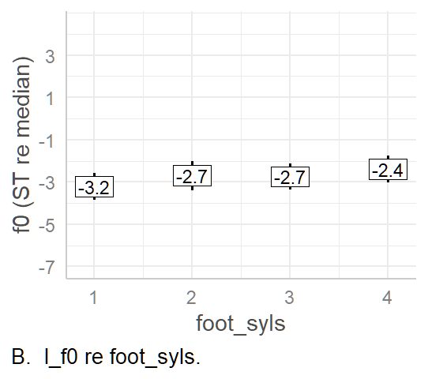

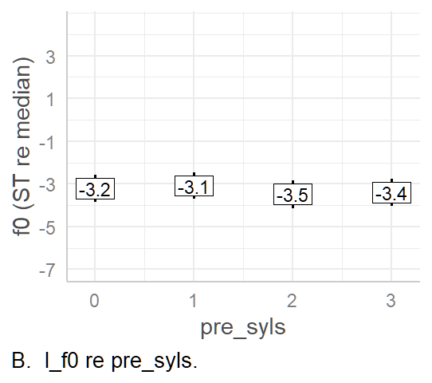

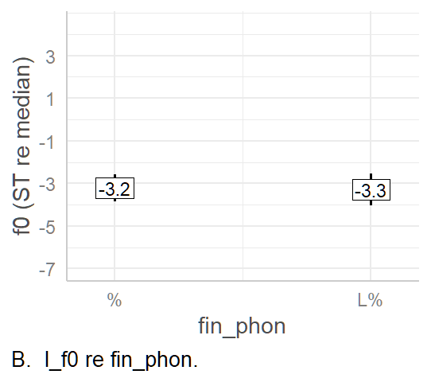

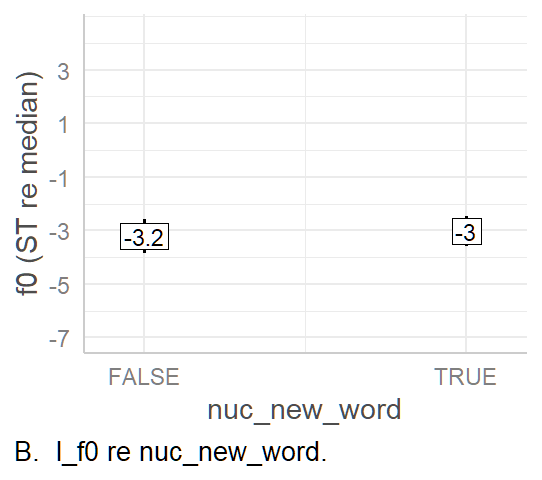

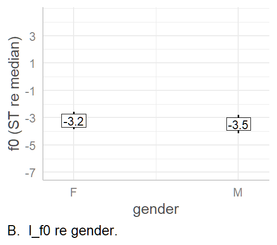

Predicted values of l_f0

| foot_syls | predicted | conf.low | conf.high | std.error |
| --- | --- | --- | --- | --- |
| 1 | -3.2 | -3.84 | -2.57 | 0.32 |
| 2 | -2.7 | -3.39 | -2.01 | 0.35 |
| 3 | -2.74 | -3.37 | -2.11 | 0.32 |
| 4 | -2.4 | -3.03 | -1.77 | 0.32 |

Predicted values of l_f0

| pre_syls | predicted | conf.low | conf.high | std.error |
| --- | --- | --- | --- | --- |
| 0 | -3.2 | -3.84 | -2.57 | 0.32 |
| 1 | -3.08 | -3.71 | -2.45 | 0.32 |
| 2 | -3.48 | -4.13 | -2.83 | 0.33 |
| 3 | -3.4 | -4.05 | -2.76 | 0.33 |

Predicted values of l_f0

| fin_phon | predicted | conf.low | conf.high | std.error |
| --- | --- | --- | --- | --- |
| % | -3.2 | -3.84 | -2.57 | 0.32 |
| L% | -3.29 | -4.03 | -2.55 | 0.38 |

Predicted values of l_f0

| nuc_new_word | predicted | conf.low | conf.high | std.error |
| --- | --- | --- | --- | --- |
| FALSE | -3.2 | -3.84 | -2.57 | 0.32 |
| TRUE | -3.02 | -3.59 | -2.46 | 0.29 |

Predicted values of l_f0

| gender | predicted | conf.low | conf.high | std.error |
| --- | --- | --- | --- | --- |
| F | -3.2 | -3.84 | -2.57 | 0.32 |
| M | -3.46 | -4.13 | -2.79 | 0.34 |

l_f0 ~ foot_syls + pre_syls + fin_phon + nuc_new_word + gender + (1 | speaker) + (1 | nuc_str_syl)

b1: l_f0 ~ foot_syls + pre_syls + fin_phon + nuc_new_word + gender +, (1 | speaker) + (1 | nuc_str_syl)

| intercept | slope | estimate | conf.low | conf.high | std.error | t.value | df | p.value |
| --- | --- | --- | --- | --- | --- | --- | --- | --- |
| foot_syls1 | foot_syls2 | 0.5 | 0.2 | 0.8 | 0.16 | 3.08 | 749.68 | .002 |
| foot_syls1 | foot_syls3 | 0.5 | 0.2 | 0.7 | 0.13 | 3.58 | 749.7 | < .001 |
| foot_syls1 | foot_syls4 | 0.8 | 0.4 | 1.2 | 0.2 | 4.04 | 279.87 | < .001 |
| foot_syls2 | foot_syls3 | 0.0 | -0.4 | 0.3 | 0.17 | -0.26 | 749.95 | .797 |
| foot_syls2 | foot_syls4 | 0.3 | -0.1 | 0.7 | 0.21 | 1.46 | 303.32 | .144 |
| foot_syls3 | foot_syls4 | 0.3 | -0.1 | 0.8 | 0.21 | 1.67 | 305.73 | .095 |
| pre_syls0 | pre_syls1 | 0.1 | -0.1 | 0.4 | 0.13 | 0.94 | 749.91 | .346 |
| pre_syls0 | pre_syls2 | -0.3 | -0.7 | 0.1 | 0.2 | -1.39 | 260.78 | .167 |
| pre_syls0 | pre_syls3 | -0.2 | -0.6 | 0.2 | 0.2 | -0.97 | 138.42 | .334 |
| pre_syls1 | pre_syls2 | -0.4 | -0.7 | -0.1 | 0.15 | -2.65 | 108.97 | .009 |
| pre_syls1 | pre_syls3 | -0.3 | -0.6 | 0.0 | 0.16 | -2.06 | 53.18 | .045 |
| pre_syls2 | pre_syls3 | 0.1 | -0.1 | 0.3 | 0.1 | 0.76 | 15.53 | .456 |
| intercept | fin_phonL% | -0.1 | -0.5 | 0.3 | 0.2 | -0.41 | 755.56 | .682 |
| intercept | nuc_new_wordT | 0.2 | 0.0 | 0.4 | 0.12 | 1.57 | 44.16 | .123 |
| intercept | genderM | -0.3 | -1.1 | 0.6 | 0.38 | -0.67 | 8.98 | .52 |

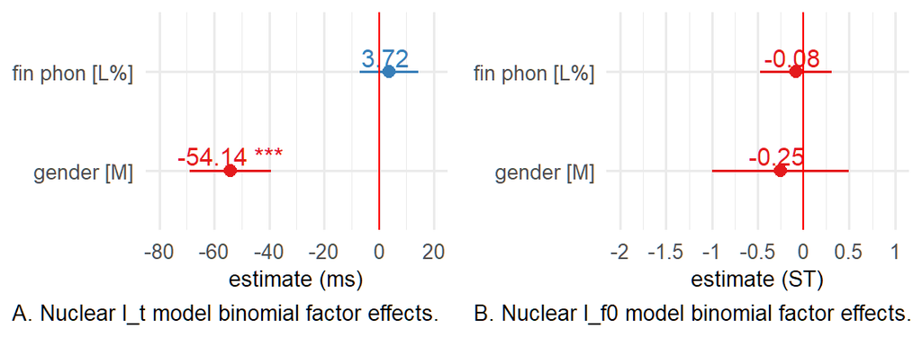

### H targets

#### Analysis of H timing

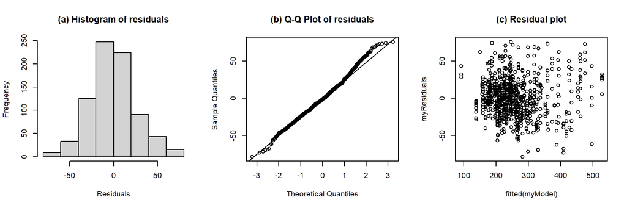

```
##
## Formula:
## h_t ~ foot_syls + pre_syls + fin_phon + nuc_new_word + gender +, (1 | speaker) + (1 | nuc_str_syl)
##
## Linear mixed model fit by REML. t-tests use Satterthwaite's method [
## lmerModLmerTest]
## Formula: h_t_equation
##    Data: nuc_data %>% filter(abs(scale(resid(nuc_h_t_mdl))) <= 3)
## Control:
## lmerControl(optimizer = optimizer, calc.derivs = F, optCtrl = list(method = "nlminb",
##     starttests = F, kkt = F))
##
## REML criterion at convergence: 7363.6
##
## Scaled residuals:
##      Min       1Q   Median       3Q      Max
## -2.98998 -0.67401 -0.05753  0.59246  2.88175
##
## Random effects:
##  Groups      Name        Variance Std.Dev.
##  speaker     (Intercept) 591.7    24.32
##  nuc_str_syl (Intercept) 689.1    26.25
##  Residual                688.5    26.24
## Number of obs: 786, groups:  speaker, 11; nuc_str_syl, 3
##
## Fixed effects:
##                  Estimate Std. Error      df t value Pr(>|t|)
## (Intercept)       292.368     19.173   4.746  15.249 3.26e-05 ***
## foot_syls2         21.226      4.808 765.110   4.415 1.16e-05 ***
## foot_syls3         95.949      3.810 765.105  25.185  < 2e-16 ***
## foot_syls4        218.552      6.062 766.738  36.053  < 2e-16 ***
## pre_syls1         -33.472      3.830 765.247  -8.740  < 2e-16 ***
## pre_syls2         -37.785      6.072 766.966  -6.223 8.02e-10 ***
## pre_syls3         -44.687      6.286 767.187  -7.109 2.69e-12 ***
## fin_phonL%        -45.810      5.919 768.383  -7.740 3.14e-14 ***
## nuc_new_wordTRUE  -12.681      3.712 766.455  -3.416 0.000668 ***
## genderM           -64.322     14.850   9.006  -4.331 0.001898 **
## ---
## Signif. codes:  0 '***' 0.001 '**' 0.01 '*' 0.05 '.' 0.1 ' ' 1
##
## Correlation of Fixed Effects:
##             (Intr) ft_sy2 ft_sy3 ft_sy4 pr_sy1 pr_sy2 pr_sy3 fn_pL% n__TRU
## foot_syls2  -0.031
## foot_syls3  -0.099  0.315
## foot_syls4  -0.186  0.358  0.254
## pre_syls1   -0.098 -0.413  0.098 -0.325
## pre_syls2   -0.160 -0.690  0.063 -0.018  0.631
## pre_syls3   -0.173 -0.668  0.062  0.016  0.611  0.821
## fin_phonL%  -0.009  0.071 -0.050 -0.013 -0.029 -0.027 -0.042
## nc_nw_wTRUE -0.265 -0.003  0.002  0.612  0.002  0.306  0.351 -0.027
## genderM     -0.353 -0.002  0.001  0.000  0.003  0.003  0.005  0.002  0.003
```

ANOVA of model: h_t ~ foot_syls + pre_syls + fin_phon + nuc_new_word + gender +, (1 | speaker) + (1 | nuc_str_syl)

| term | sumsq | meansq | NumDF | DenDF | F value | p.value | p.adj (BH) | signif. |
| --- | --- | --- | --- | --- | --- | --- | --- | --- |
| foot_syls | 1212233 | 404078 | 3 | 765.88 | 586.86 | < .001 | < .001 | *p* < .05 |
| pre_syls | 56659 | 18886 | 3 | 763.69 | 27.43 | < .001 | < .001 | *p* < .05 |
| fin_phon | 41246 | 41246 | 1 | 768.38 | 59.9 | < .001 | < .001 | *p* < .05 |
| nuc_new_word | 8036 | 8036 | 1 | 766.46 | 11.67 | < .001 | .001 | *p* < .05 |
| gender | 12918 | 12918 | 1 | 9.01 | 18.76 | .002 | .004 | *p* < .05 |

Omega<sup>2</sup> (partial) for Dependent variable.

| Parameter | ω<sup>2</sup><sub>*p*</sub> | 95% CI |
| --- | --- | --- |
| foot_syls | .7 | [.6, .73] |
| pre_syls | .09 | [.06, .13] |
| fin_phon | .07 | [.04, .11] |
| nuc_new_word | .01 | [0, .03] |
| gender | .62 | [.13, .82] |

Conditional and marginal R<sup>2</sup>

| marginal R<sup>2</sup> | conditional R<sup>2</sup> |
| --- | --- |
| .71 | .9 |

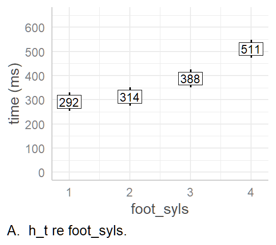

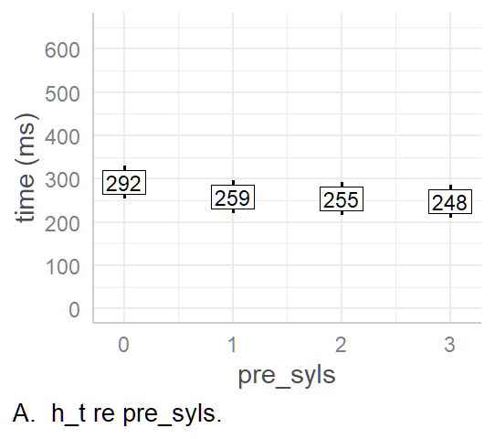

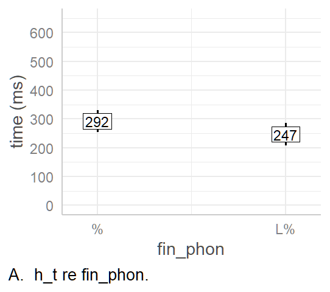

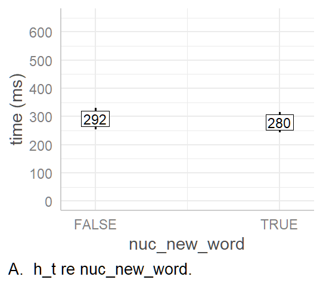

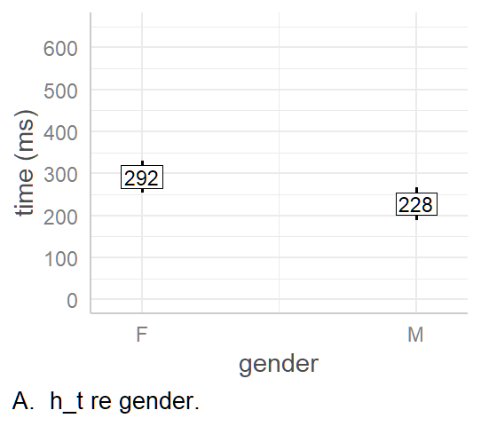

Predicted values of h_t

| foot_syls | predicted | conf.low | conf.high | std.error |
| --- | --- | --- | --- | --- |
| 1 | 292.37 | 254.73 | 330.01 | 19.17 |
| 2 | 313.59 | 275.08 | 352.11 | 19.62 |
| 3 | 388.32 | 350.68 | 425.95 | 19.17 |
| 4 | 510.92 | 473.62 | 548.22 | 19 |

Predicted values of h_t

| pre_syls | predicted | conf.low | conf.high | std.error |
| --- | --- | --- | --- | --- |
| 0 | 292.37 | 254.73 | 330.01 | 19.17 |
| 1 | 258.9 | 221.24 | 296.55 | 19.18 |
| 2 | 254.58 | 216.97 | 292.2 | 19.16 |
| 3 | 247.68 | 210.16 | 285.2 | 19.11 |

Predicted values of h_t

| fin_phon | predicted | conf.low | conf.high | std.error |
| --- | --- | --- | --- | --- |
| % | 292.37 | 254.73 | 330.01 | 19.17 |
| L% | 246.56 | 207.27 | 285.85 | 20.01 |

Predicted values of h_t

| nuc_new_word | predicted | conf.low | conf.high | std.error |
| --- | --- | --- | --- | --- |
| FALSE | 292.37 | 254.73 | 330.01 | 19.17 |
| TRUE | 279.69 | 243.29 | 316.08 | 18.54 |

Predicted values of h_t

| gender | predicted | conf.low | conf.high | std.error |
| --- | --- | --- | --- | --- |
| F | 292.37 | 254.73 | 330.01 | 19.17 |
| M | 228.05 | 189.43 | 266.66 | 19.67 |

h_t ~ foot_syls + pre_syls + fin_phon + nuc_new_word + gender + (1 | speaker) + (1 | nuc_str_syl)

b1: h_t ~ foot_syls + pre_syls + fin_phon + nuc_new_word + gender +, (1 | speaker) + (1 | nuc_str_syl)

| intercept | slope | estimate | conf.low | conf.high | std.error | t.value | df | p.value |
| --- | --- | --- | --- | --- | --- | --- | --- | --- |
| foot_syls1 | foot_syls2 | 21 | 12 | 31 | 4.81 | 4.41 | 765.11 | < .001 |
| foot_syls1 | foot_syls3 | 96 | 88 | 103 | 3.81 | 25.18 | 765.1 | < .001 |
| foot_syls1 | foot_syls4 | 219 | 207 | 230 | 6.06 | 36.05 | 766.74 | < .001 |
| foot_syls2 | foot_syls3 | 75 | 65 | 85 | 5.11 | 14.63 | 765.25 | < .001 |
| foot_syls2 | foot_syls4 | 197 | 185 | 210 | 6.24 | 31.6 | 766.66 | < .001 |
| foot_syls3 | foot_syls4 | 123 | 110 | 135 | 6.29 | 19.5 | 766.72 | < .001 |
| pre_syls0 | pre_syls1 | -34 | -41 | -26 | 3.83 | -8.74 | 765.25 | < .001 |
| pre_syls0 | pre_syls2 | -38 | -50 | -26 | 6.07 | -6.22 | 766.97 | < .001 |
| pre_syls0 | pre_syls3 | -45 | -57 | -32 | 6.29 | -7.11 | 767.19 | < .001 |
| pre_syls1 | pre_syls2 | -4 | -14 | 5 | 4.71 | -0.92 | 766.95 | .36 |
| pre_syls1 | pre_syls3 | -11 | -21 | -1 | 4.98 | -2.25 | 766 | .024 |
| pre_syls2 | pre_syls3 | -7 | -14 | 0 | 3.7 | -1.86 | 751.16 | .063 |
| intercept | fin_phonL% | -46 | -57 | -34 | 5.92 | -7.74 | 768.38 | < .001 |
| intercept | nuc_new_wordT | -13 | -20 | -5 | 3.71 | -3.42 | 766.46 | < .001 |
| intercept | genderM | -64 | -98 | -31 | 14.85 | -4.33 | 9.01 | .002 |

#### Analysis of H F0

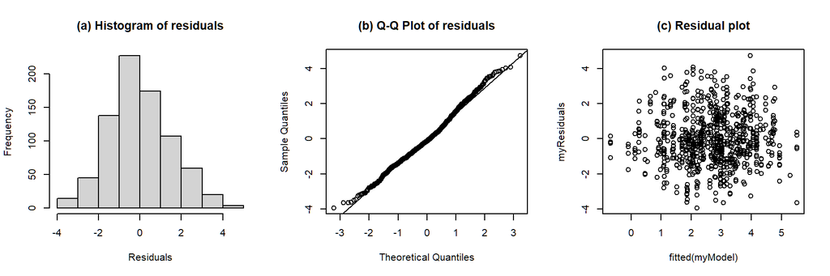

```
##
## Formula:
## h_f0 ~ foot_syls + pre_syls + fin_phon + nuc_new_word + gender +, (1 | speaker) + (1 | nuc_str_syl)
##
## Linear mixed model fit by REML. t-tests use Satterthwaite's method [
## lmerModLmerTest]
## Formula: h_f0_equation
##    Data: nuc_data %>% filter(abs(scale(resid(nuc_h_f0_mdl))) <= 4)
## Control:
## lmerControl(optimizer = optimizer, calc.derivs = F, optCtrl = list(method = "nlminb",
##     starttests = F, kkt = F))
##
## REML criterion at convergence: 2915.8
##
## Scaled residuals:
##     Min      1Q  Median      3Q     Max
## -2.6221 -0.6663 -0.1041  0.6423  3.1530
##
## Random effects:
##  Groups      Name        Variance Std.Dev.
##  speaker     (Intercept) 0.9098   0.9538
##  nuc_str_syl (Intercept) 0.4128   0.6425
##  Residual                2.2501   1.5000
## Number of obs: 787, groups:  speaker, 11; nuc_str_syl, 3
##
## Fixed effects:
##                   Estimate Std. Error        df t value Pr(>|t|)
## (Intercept)        0.72839    0.64398  11.81951   1.131 0.280457
## foot_syls2         0.84635    0.27474 766.16016   3.081 0.002140 **
## foot_syls3         2.29420    0.21723 766.17035  10.561  < 2e-16 ***
## foot_syls4         2.00642    0.34513 758.92204   5.813 9.01e-09 ***
## pre_syls1          0.82007    0.21852 766.43100   3.753 0.000188 ***
## pre_syls2          0.74566    0.34543 752.93859   2.159 0.031191 *
## pre_syls3          1.14703    0.35690 725.27574   3.214 0.001367 **
## fin_phonL%        -0.64126    0.33787 772.26023  -1.898 0.058077 .
## nuc_new_wordTRUE   0.44109    0.20998 667.70901   2.101 0.036047 *
## genderM            0.09731    0.58757   8.98828   0.166 0.872129
## ---
## Signif. codes:  0 '***' 0.001 '**' 0.01 '*' 0.05 '.' 0.1 ' ' 1
##
## Correlation of Fixed Effects:
##             (Intr) ft_sy2 ft_sy3 ft_sy4 pr_sy1 pr_sy2 pr_sy3 fn_pL% n__TRU
## foot_syls2  -0.053
## foot_syls3  -0.170  0.314
## foot_syls4  -0.311  0.359  0.254
## pre_syls1   -0.166 -0.412  0.103 -0.325
## pre_syls2   -0.268 -0.693  0.066 -0.024  0.633
## pre_syls3   -0.290 -0.672  0.065  0.010  0.614  0.827
## fin_phonL%  -0.015  0.071 -0.049 -0.013 -0.030 -0.027 -0.043
## nc_nw_wTRUE -0.443 -0.003  0.002  0.608  0.002  0.301  0.346 -0.027
## genderM     -0.417 -0.003  0.001  0.000  0.005  0.005  0.007  0.004  0.004
```

ANOVA of model: h_f0 ~ foot_syls + pre_syls + fin_phon + nuc_new_word + gender +, (1 | speaker) + (1 | nuc_str_syl)

| term | sumsq | meansq | NumDF | DenDF | F value | p.value | p.adj (BH) | signif. |
| --- | --- | --- | --- | --- | --- | --- | --- | --- |
| foot_syls | 278.32 | 92.77 | 3 | 766.63 | 41.23 | < .001 | < .001 | *p* < .05 |
| pre_syls | 40.36 | 13.45 | 3 | 607.56 | 5.98 | < .001 | .001 | *p* < .05 |
| fin_phon | 8.11 | 8.11 | 1 | 772.26 | 3.6 | .058 | .088 |  |
| nuc_new_word | 9.93 | 9.93 | 1 | 667.71 | 4.41 | .036 | .057 |  |
| gender | 0.06 | 0.06 | 1 | 8.99 | 0.03 | .872 | .896 |  |

Omega<sup>2</sup> (partial) for h_f0.

| Parameter | ω<sup>2</sup><sub>*p*</sub> | 95% CI |
| --- | --- | --- |
| foot_syls | .14 | [.09, .18] |
| pre_syls | .02 | [0, .05] |
| fin_phon | 0 | [0, .02] |
| nuc_new_word | .01 | [0, .02] |
| gender | 0 | [0, 0] |

Conditional and marginal R<sup>2</sup>

| marginal R<sup>2</sup> | conditional R<sup>2</sup> |
| --- | --- |
| .11 | .44 |

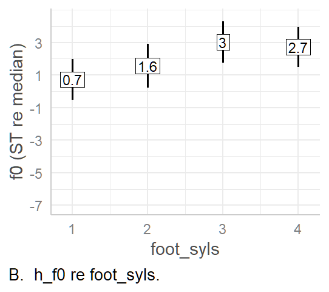

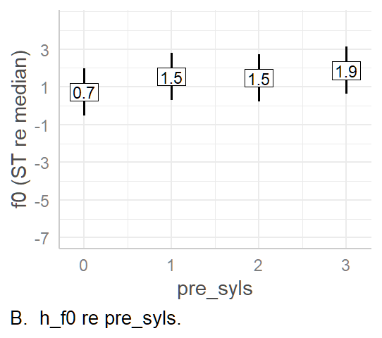

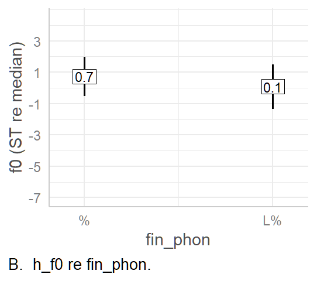

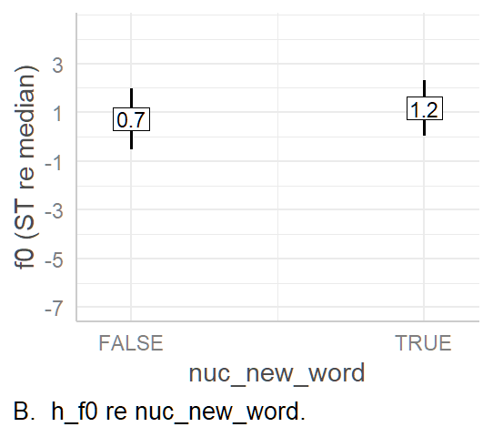

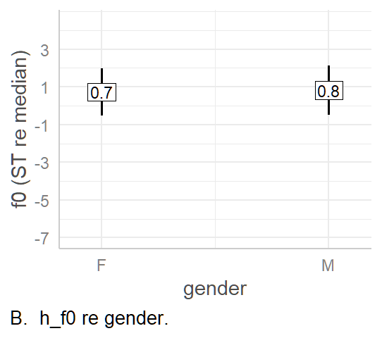

Predicted values of h_f0

| foot_syls | predicted | conf.low | conf.high | std.error |
| --- | --- | --- | --- | --- |
| 1 | 0.73 | -0.54 | 1.99 | 0.64 |
| 2 | 1.57 | 0.23 | 2.92 | 0.69 |
| 3 | 3.02 | 1.76 | 4.29 | 0.64 |
| 4 | 2.73 | 1.5 | 3.97 | 0.63 |

Predicted values of h_f0

| pre_syls | predicted | conf.low | conf.high | std.error |
| --- | --- | --- | --- | --- |
| 0 | 0.73 | -0.54 | 1.99 | 0.64 |
| 1 | 1.55 | 0.28 | 2.81 | 0.64 |
| 2 | 1.47 | 0.21 | 2.74 | 0.64 |
| 3 | 1.88 | 0.62 | 3.13 | 0.64 |

Predicted values of h_f0

| fin_phon | predicted | conf.low | conf.high | std.error |
| --- | --- | --- | --- | --- |
| % | 0.73 | -0.54 | 1.99 | 0.64 |
| L% | 0.09 | -1.33 | 1.51 | 0.72 |

Predicted values of h_f0

| nuc_new_word | predicted | conf.low | conf.high | std.error |
| --- | --- | --- | --- | --- |
| FALSE | 0.73 | -0.54 | 1.99 | 0.64 |
| TRUE | 1.17 | 0.03 | 2.31 | 0.58 |

Predicted values of h_f0

| gender | predicted | conf.low | conf.high | std.error |
| --- | --- | --- | --- | --- |
| F | 0.73 | -0.54 | 1.99 | 0.64 |
| M | 0.83 | -0.48 | 2.13 | 0.67 |

h_f0 ~ foot_syls + pre_syls + fin_phon + nuc_new_word + gender + (1 | speaker) + (1 | nuc_str_syl)

b1: h_f0 ~ foot_syls + pre_syls + fin_phon + nuc_new_word + gender +, (1 | speaker) + (1 | nuc_str_syl)

| intercept | slope | estimate | conf.low | conf.high | std.error | t.value | df | p.value |
| --- | --- | --- | --- | --- | --- | --- | --- | --- |
| foot_syls1 | foot_syls2 | 0.8 | 0.3 | 1.4 | 0.27 | 3.08 | 766.16 | .002 |
| foot_syls1 | foot_syls3 | 2.3 | 1.9 | 2.7 | 0.22 | 10.56 | 766.17 | < .001 |
| foot_syls1 | foot_syls4 | 2.0 | 1.3 | 2.7 | 0.35 | 5.81 | 758.92 | < .001 |
| foot_syls2 | foot_syls3 | 1.4 | 0.9 | 2.0 | 0.29 | 4.96 | 766.46 | < .001 |
| foot_syls2 | foot_syls4 | 1.2 | 0.5 | 1.9 | 0.36 | 3.26 | 760.43 | .001 |
| foot_syls3 | foot_syls4 | -0.3 | -1.0 | 0.4 | 0.36 | -0.8 | 760.9 | .422 |
| pre_syls0 | pre_syls1 | 0.8 | 0.4 | 1.2 | 0.22 | 3.75 | 766.43 | < .001 |
| pre_syls0 | pre_syls2 | 0.8 | 0.1 | 1.4 | 0.35 | 2.16 | 752.94 | .031 |
| pre_syls0 | pre_syls3 | 1.1 | 0.4 | 1.9 | 0.36 | 3.21 | 725.28 | .001 |
| pre_syls1 | pre_syls2 | -0.1 | -0.6 | 0.4 | 0.27 | -0.28 | 715.34 | .781 |
| pre_syls1 | pre_syls3 | 0.3 | -0.2 | 0.9 | 0.28 | 1.16 | 652.07 | .246 |
| pre_syls2 | pre_syls3 | 0.4 | 0.0 | 0.8 | 0.21 | 1.94 | 392.25 | .053 |
| intercept | fin_phonL% | -0.6 | -1.3 | 0.0 | 0.34 | -1.9 | 772.26 | .058 |
| intercept | nuc_new_wordT | 0.4 | 0.0 | 0.8 | 0.21 | 2.1 | 667.71 | .036 |
| intercept | genderM | 0.1 | -1.2 | 1.4 | 0.59 | 0.17 | 8.99 | .872 |

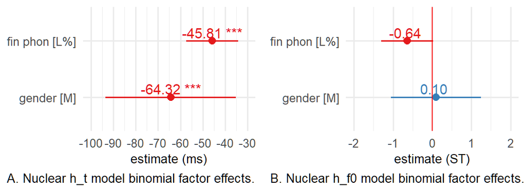

### E targets

e_t is not important for evaluation. However, the timing has been modelled just for visualisation purposes.

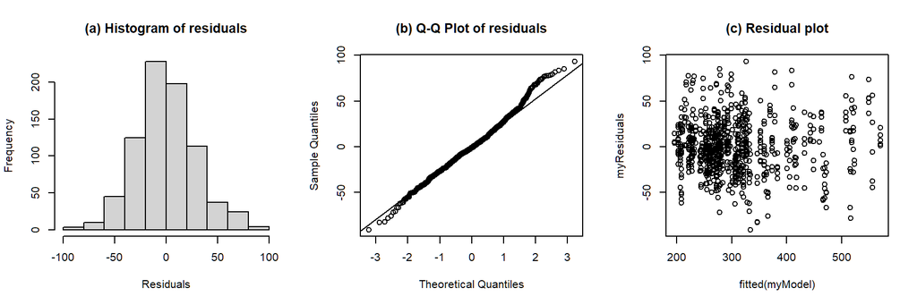

```
##
## Formula:
## e_t ~ foot_syls + pre_syls + fin_phon + nuc_new_word + gender +, (1 | speaker) + (1 | nuc_str_syl)
##
## Linear mixed model fit by REML. t-tests use Satterthwaite's method [
## lmerModLmerTest]
## Formula: e_t_equation
##    Data: nuc_data %>% filter(abs(scale(resid(nuc_e_t_mdl))) <= 4)
## Control:
## lmerControl(optimizer = optimizer, calc.derivs = F, optCtrl = list(method = "nlminb",
##     starttests = F, kkt = F))
##
## REML criterion at convergence: 7539.7
##
## Scaled residuals:
##     Min      1Q  Median      3Q     Max
## -3.1237 -0.6307 -0.0471  0.5892  3.1918
##
## Random effects:
##  Groups      Name        Variance Std.Dev.
##  speaker     (Intercept)  699.1   26.44
##  nuc_str_syl (Intercept) 1039.9   32.25
##  Residual                 853.4   29.21
## Number of obs: 787, groups:  speaker, 11; nuc_str_syl, 3
##
## Fixed effects:
##                  Estimate Std. Error      df t value Pr(>|t|)
## (Intercept)       330.004     22.625   4.134  14.586 0.000104 ***
## foot_syls2         11.413      5.355 766.108   2.131 0.033373 *
## foot_syls3        117.127      4.247 766.110  27.582  < 2e-16 ***
## foot_syls4        248.909      6.747 767.541  36.894  < 2e-16 ***
## pre_syls1         -31.242      4.273 766.237  -7.312 6.65e-13 ***
## pre_syls2         -31.400      6.766 767.775  -4.641 4.08e-06 ***
## pre_syls3         -36.048      7.006 768.183  -5.146 3.39e-07 ***
## fin_phonL%         -6.716      6.589 769.521  -1.019 0.308423
## nuc_new_wordTRUE   -5.961      4.127 767.913  -1.445 0.148995
## genderM           -47.861     16.147   9.000  -2.964 0.015857 *
## ---
## Signif. codes:  0 '***' 0.001 '**' 0.01 '*' 0.05 '.' 0.1 ' ' 1
##
## Correlation of Fixed Effects:
##             (Intr) ft_sy2 ft_sy3 ft_sy4 pr_sy1 pr_sy2 pr_sy3 fn_pL% n__TRU
## foot_syls2  -0.029
## foot_syls3  -0.095  0.309
## foot_syls4  -0.175  0.359  0.250
## pre_syls1   -0.093 -0.414  0.110 -0.325
## pre_syls2   -0.151 -0.690  0.070 -0.019  0.632
## pre_syls3   -0.164 -0.668  0.069  0.016  0.612  0.822
## fin_phonL%  -0.008  0.072 -0.050 -0.013 -0.031 -0.028 -0.043
## nc_nw_wTRUE -0.250 -0.003  0.003  0.611  0.002  0.306  0.353 -0.027
## genderM     -0.326 -0.002  0.001  0.000  0.004  0.004  0.006  0.002  0.003
```

ANOVA of model: e_t ~ foot_syls + pre_syls + fin_phon + nuc_new_word + gender +, (1 | speaker) + (1 | nuc_str_syl)

| term | sumsq | meansq | NumDF | DenDF | F value | p.value | p.adj (BH) | signif. |
| --- | --- | --- | --- | --- | --- | --- | --- | --- |
| foot_syls | 1715688 | 571896 | 3 | 766.77 | 670.13 | < .001 | < .001 | *p* < .05 |
| pre_syls | 46809 | 15603 | 3 | 766.07 | 18.28 | < .001 | < .001 | *p* < .05 |
| fin_phon | 886.52 | 886.52 | 1 | 769.52 | 1.04 | .308 | .366 |  |
| nuc_new_word | 1781 | 1781 | 1 | 767.91 | 2.09 | .149 | .195 |  |
| gender | 7497 | 7497 | 1 | 9 | 8.79 | .016 | .029 | *p* < .05 |

Omega<sup>2</sup> (partial) for e_t.

| Parameter | ω<sup>2</sup><sub>*p*</sub> | 95% CI |
| --- | --- | --- |
| foot_syls | .72 | [.63, .75] |
| pre_syls | .06 | [.03, .1] |
| fin_phon | 0 | [0, 0] |
| nuc_new_word | 0 | [0, .01] |
| gender | .41 | [0, .71] |

Conditional and marginal R<sup>2</sup>

| marginal R<sup>2</sup> | conditional R<sup>2</sup> |
| --- | --- |
| .68 | .9 |

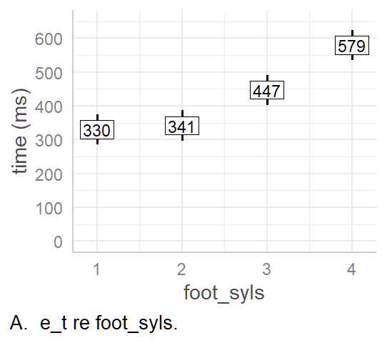

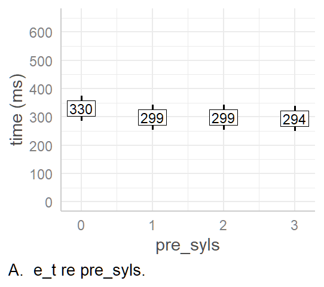

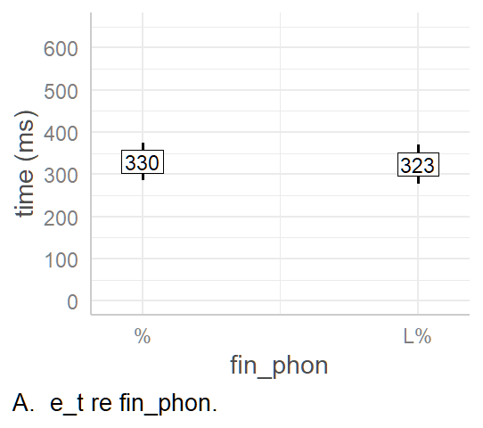

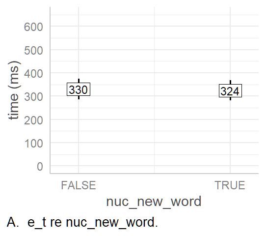

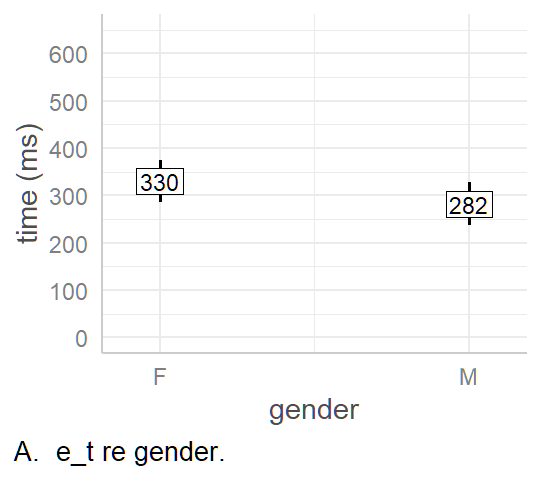

Predicted values of e_t

| foot_syls | predicted | conf.low | conf.high | std.error |
| --- | --- | --- | --- | --- |
| 1 | 330 | 285.59 | 374.42 | 22.63 |
| 2 | 341.42 | 296.08 | 386.76 | 23.1 |
| 3 | 447.13 | 402.73 | 491.54 | 22.62 |
| 4 | 578.91 | 534.85 | 622.98 | 22.45 |

Predicted values of e_t

| pre_syls | predicted | conf.low | conf.high | std.error |
| --- | --- | --- | --- | --- |
| 0 | 330 | 285.59 | 374.42 | 22.63 |
| 1 | 298.76 | 254.33 | 343.19 | 22.63 |
| 2 | 298.6 | 254.22 | 342.99 | 22.61 |
| 3 | 293.96 | 249.67 | 338.24 | 22.56 |

Predicted values of e_t

| fin_phon | predicted | conf.low | conf.high | std.error |
| --- | --- | --- | --- | --- |
| % | 330 | 285.59 | 374.42 | 22.63 |
| L% | 323.29 | 277.13 | 369.44 | 23.51 |

Predicted values of e_t

| nuc_new_word | predicted | conf.low | conf.high | std.error |
| --- | --- | --- | --- | --- |
| FALSE | 330 | 285.59 | 374.42 | 22.63 |
| TRUE | 324.04 | 280.93 | 367.15 | 21.96 |

Predicted values of e_t

| gender | predicted | conf.low | conf.high | std.error |
| --- | --- | --- | --- | --- |
| F | 330 | 285.59 | 374.42 | 22.63 |
| M | 282.14 | 236.75 | 327.54 | 23.12 |

e_t ~ foot_syls + pre_syls + fin_phon + nuc_new_word + gender + (1 | speaker) + (1 | nuc_str_syl)

b1: e_t ~ foot_syls + pre_syls + fin_phon + nuc_new_word + gender +, (1 | speaker) + (1 | nuc_str_syl)

| intercept | slope | estimate | conf.low | conf.high | std.error | t.value | df | p.value |
| --- | --- | --- | --- | --- | --- | --- | --- | --- |
| foot_syls1 | foot_syls2 | 11 | 1 | 22 | 5.35 | 2.13 | 766.11 | .033 |
| foot_syls1 | foot_syls3 | 117 | 109 | 126 | 4.25 | 27.58 | 766.11 | < .001 |
| foot_syls1 | foot_syls4 | 249 | 236 | 262 | 6.75 | 36.89 | 767.54 | < .001 |
| foot_syls2 | foot_syls3 | 106 | 94 | 117 | 5.71 | 18.51 | 766.25 | < .001 |
| foot_syls2 | foot_syls4 | 238 | 224 | 251 | 6.95 | 34.18 | 767.46 | < .001 |
| foot_syls3 | foot_syls4 | 132 | 118 | 146 | 7.02 | 18.78 | 767.51 | < .001 |
| pre_syls0 | pre_syls1 | -31 | -40 | -23 | 4.27 | -7.31 | 766.24 | < .001 |
| pre_syls0 | pre_syls2 | -31 | -45 | -18 | 6.77 | -4.64 | 767.78 | < .001 |
| pre_syls0 | pre_syls3 | -36 | -50 | -22 | 7.01 | -5.15 | 768.18 | < .001 |
| pre_syls1 | pre_syls2 | 0 | -10 | 10 | 5.24 | -0.03 | 768.01 | .976 |
| pre_syls1 | pre_syls3 | -5 | -16 | 6 | 5.54 | -0.87 | 767.74 | .386 |
| pre_syls2 | pre_syls3 | -5 | -13 | 3 | 4.11 | -1.13 | 758.91 | .259 |
| intercept | fin_phonL% | -7 | -20 | 6 | 6.59 | -1.02 | 769.52 | .308 |
| intercept | nuc_new_wordT | -6 | -14 | 2 | 4.13 | -1.45 | 767.91 | .149 |
| intercept | genderM | -48 | -84 | -11 | 16.15 | -2.96 | 9 | .016 |

#### Analysis of E F0

- model needs trimming (|sd| residuals > 3.5)

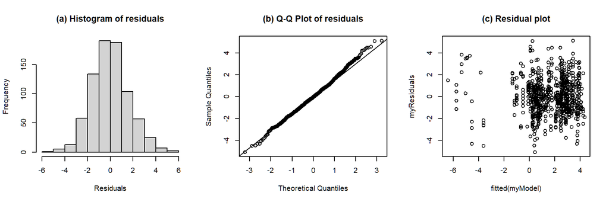

```
##
## Formula:
## e_f0 ~ foot_syls + pre_syls + fin_phon + nuc_new_word + gender +, (1 | speaker) + (1 | nuc_str_syl)
##
## Linear mixed model fit by REML. t-tests use Satterthwaite's method [
## lmerModLmerTest]
## Formula: e_f0_equation
##    Data: nuc_data %>% filter(abs(scale(resid(nuc_e_f0_mdl))) <= 3.5)
## Control:
## lmerControl(optimizer = optimizer, calc.derivs = F, optCtrl = list(method = "nlminb",
##     starttests = F, kkt = F))
##
## REML criterion at convergence: 3055.8
##
## Scaled residuals:
##      Min       1Q   Median       3Q      Max
## -3.08780 -0.66934 -0.03013  0.59134  3.10446
##
## Random effects:
##  Groups      Name        Variance Std.Dev.
##  speaker     (Intercept) 1.8468   1.359
##  nuc_str_syl (Intercept) 0.2275   0.477
##  Residual                2.7100   1.646
## Number of obs: 785, groups:  speaker, 11; nuc_str_syl, 3
##
## Fixed effects:
##                  Estimate Std. Error       df t value Pr(>|t|)
## (Intercept)        0.2233     0.7283  17.5324   0.307   0.7627
## foot_syls2         1.3654     0.3015 763.9825   4.528 6.90e-06 ***
## foot_syls3         1.6618     0.2384 763.9879   6.970 6.84e-12 ***
## foot_syls4         1.6544     0.3785 705.2020   4.371 1.42e-05 ***
## pre_syls1          0.4996     0.2398 764.1468   2.083   0.0376 *
## pre_syls2          0.2307     0.3772 679.2374   0.612   0.5411
## pre_syls3          0.5730     0.3887 579.6235   1.474   0.1410
## fin_phonL%        -5.6016     0.3712 768.3282 -15.092  < 2e-16 ***
## nuc_new_wordTRUE   0.2754     0.2278 420.4950   1.209   0.2273
## genderM           -0.7209     0.8314   8.9850  -0.867   0.4084
## ---
## Signif. codes:  0 '***' 0.001 '**' 0.01 '*' 0.05 '.' 0.1 ' ' 1
##
## Correlation of Fixed Effects:
##             (Intr) ft_sy2 ft_sy3 ft_sy4 pr_sy1 pr_sy2 pr_sy3 fn_pL% n__TRU
## foot_syls2  -0.052
## foot_syls3  -0.165  0.314
## foot_syls4  -0.294  0.360  0.254
## pre_syls1   -0.161 -0.412  0.103 -0.326
## pre_syls2   -0.254 -0.696  0.066 -0.031  0.636
## pre_syls3   -0.274 -0.677  0.066  0.000  0.619  0.834
## fin_phonL%  -0.014  0.071 -0.050 -0.014 -0.030 -0.026 -0.045
## nc_nw_wTRUE -0.421 -0.003  0.002  0.602  0.002  0.295  0.337 -0.029
## genderM     -0.521 -0.002  0.001  0.000  0.004  0.004  0.005  0.003  0.003
```

ANOVA of model: e_f0 ~ foot_syls + pre_syls + fin_phon + nuc_new_word + gender +, (1 | speaker) + (1 | nuc_str_syl)

| term | sumsq | meansq | NumDF | DenDF | F value | p.value | p.adj (BH) | signif. |
| --- | --- | --- | --- | --- | --- | --- | --- | --- |
| foot_syls | 159.34 | 53.12 | 3 | 754.12 | 19.6 | < .001 | < .001 | *p* < .05 |
| pre_syls | 18.81 | 6.27 | 3 | 330.09 | 2.31 | .076 | .107 |  |
| fin_phon | 617.26 | 617.26 | 1 | 768.33 | 227.77 | < .001 | < .001 | *p* < .05 |
| nuc_new_word | 3.96 | 3.96 | 1 | 420.5 | 1.46 | .227 | .288 |  |
| gender | 2.04 | 2.04 | 1 | 8.98 | 0.75 | .408 | .47 |  |

Omega<sup>2</sup> (partial) for e_f0.

| Parameter | ω<sup>2</sup><sub>*p*</sub> | 95% CI |
| --- | --- | --- |
| foot_syls | .07 | [.04, .1] |
| pre_syls | .01 | [0, .04] |
| fin_phon | .23 | [.18, .28] |
| nuc_new_word | 0 | [0, .02] |
| gender | 0 | [0, 0] |

Conditional and marginal R<sup>2</sup>

| marginal R<sup>2</sup> | conditional R<sup>2</sup> |
| --- | --- |
| .22 | .56 |

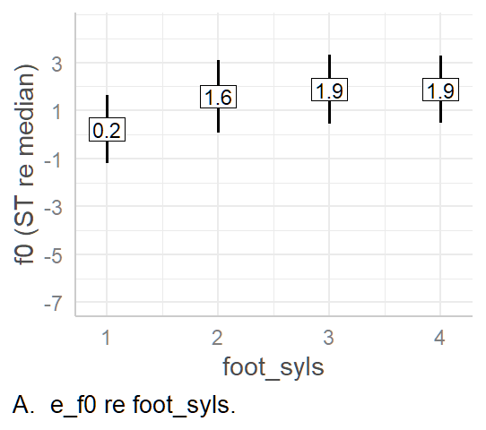

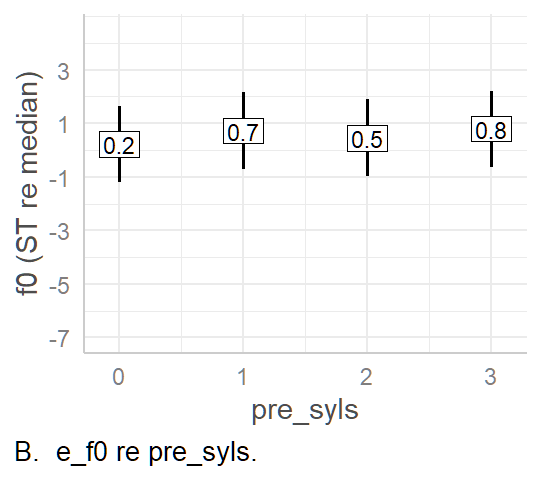

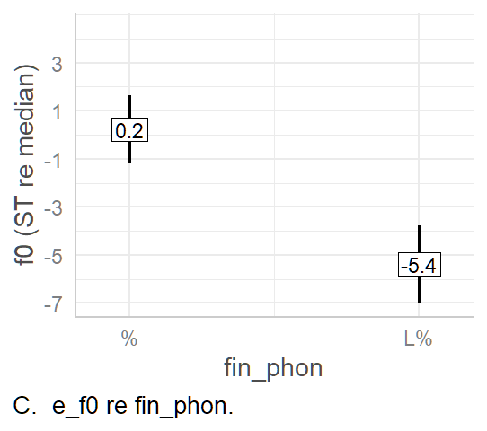

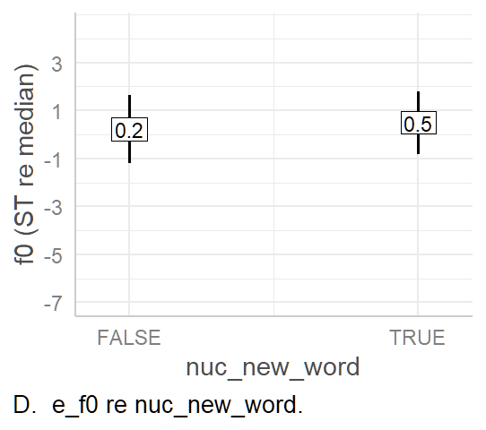

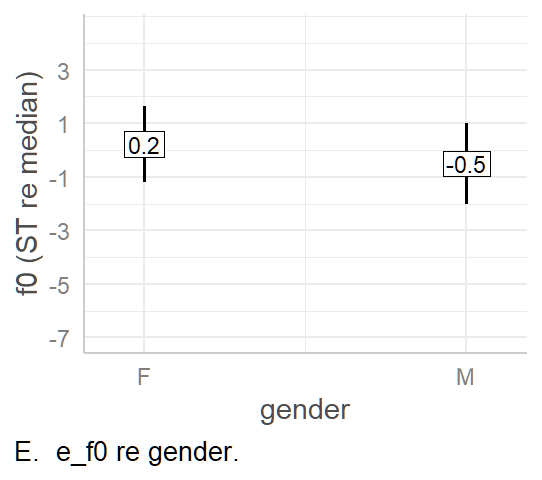

Predicted values of e_f0

| foot_syls | predicted | conf.low | conf.high | std.error |
| --- | --- | --- | --- | --- |
| 1 | 0.22 | -1.21 | 1.65 | 0.73 |
| 2 | 1.59 | 0.07 | 3.11 | 0.77 |
| 3 | 1.89 | 0.46 | 3.31 | 0.73 |
| 4 | 1.88 | 0.47 | 3.28 | 0.72 |

Predicted values of e_f0

| pre_syls | predicted | conf.low | conf.high | std.error |
| --- | --- | --- | --- | --- |
| 0 | 0.22 | -1.21 | 1.65 | 0.73 |
| 1 | 0.72 | -0.71 | 2.15 | 0.73 |
| 2 | 0.45 | -0.98 | 1.89 | 0.73 |
| 3 | 0.8 | -0.63 | 2.22 | 0.73 |

Predicted values of e_f0

| fin_phon | predicted | conf.low | conf.high | std.error |
| --- | --- | --- | --- | --- |
| % | 0.22 | -1.21 | 1.65 | 0.73 |
| L% | -5.38 | -6.97 | -3.78 | 0.81 |

Predicted values of e_f0

| nuc_new_word | predicted | conf.low | conf.high | std.error |
| --- | --- | --- | --- | --- |
| FALSE | 0.22 | -1.21 | 1.65 | 0.73 |
| TRUE | 0.5 | -0.81 | 1.8 | 0.67 |

Predicted values of e_f0

| gender | predicted | conf.low | conf.high | std.error |
| --- | --- | --- | --- | --- |
| F | 0.22 | -1.21 | 1.65 | 0.73 |
| M | -0.5 | -2.01 | 1.01 | 0.77 |

e_f0 ~ foot_syls + pre_syls + fin_phon + nuc_new_word + gender + (1 | speaker) + (1 | nuc_str_syl)

b1: e_f0 ~ foot_syls + pre_syls + fin_phon + nuc_new_word + gender +, (1 | speaker) + (1 | nuc_str_syl)

| intercept | slope | estimate | conf.low | conf.high | std.error | t.value | df | p.value |
| --- | --- | --- | --- | --- | --- | --- | --- | --- |
| foot_syls1 | foot_syls2 | 1.4 | 0.8 | 2.0 | 0.3 | 4.53 | 763.98 | < .001 |
| foot_syls1 | foot_syls3 | 1.7 | 1.2 | 2.1 | 0.24 | 6.97 | 763.99 | < .001 |
| foot_syls1 | foot_syls4 | 1.6 | 0.9 | 2.4 | 0.38 | 4.37 | 705.2 | < .001 |
| foot_syls2 | foot_syls3 | 0.3 | -0.3 | 0.9 | 0.32 | 0.93 | 764.17 | .355 |
| foot_syls2 | foot_syls4 | 0.3 | -0.5 | 1.0 | 0.39 | 0.74 | 712.92 | .459 |
| foot_syls3 | foot_syls4 | 0.0 | -0.8 | 0.8 | 0.39 | -0.02 | 714.71 | .985 |
| pre_syls0 | pre_syls1 | 0.5 | 0.0 | 1.0 | 0.24 | 2.08 | 764.15 | .038 |
| pre_syls0 | pre_syls2 | 0.2 | -0.5 | 1.0 | 0.38 | 0.61 | 679.24 | .541 |
| pre_syls0 | pre_syls3 | 0.6 | -0.2 | 1.3 | 0.39 | 1.47 | 579.62 | .141 |
| pre_syls1 | pre_syls2 | -0.3 | -0.8 | 0.3 | 0.29 | -0.92 | 546.41 | .356 |
| pre_syls1 | pre_syls3 | 0.1 | -0.5 | 0.7 | 0.31 | 0.24 | 402.46 | .81 |
| pre_syls2 | pre_syls3 | 0.3 | -0.1 | 0.8 | 0.22 | 1.55 | 142.39 | .123 |
| intercept | fin_phonL% | -5.6 | -6.3 | -4.9 | 0.37 | -15.09 | 768.33 | < .001 |
| intercept | nuc_new_wordT | 0.3 | -0.2 | 0.7 | 0.23 | 1.21 | 420.49 | .227 |
| intercept | genderM | -0.7 | -2.6 | 1.2 | 0.83 | -0.87 | 8.99 | .408 |

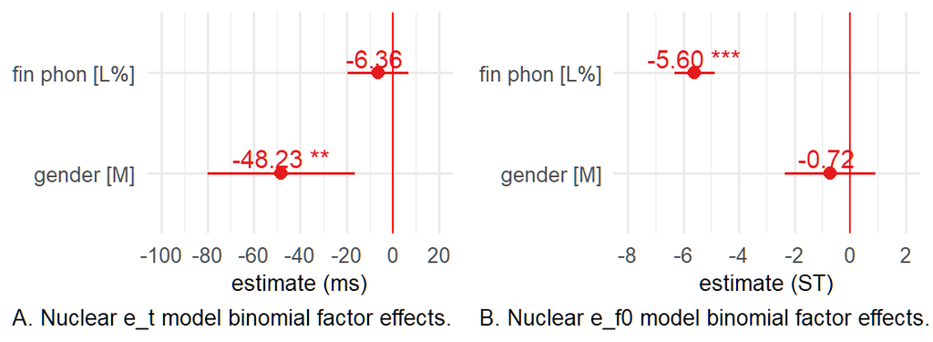

### Truncation and Compression Effects

#### LH Excursion

- model needs trimming (|sd| residuals > 2.5)

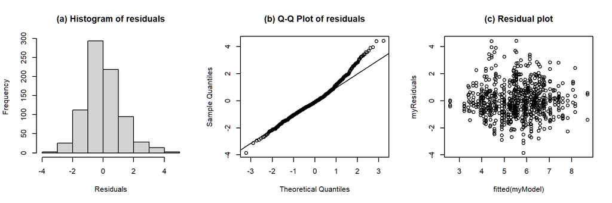

```
## Searching for good optimization settings with optimizeModel().
##   Formula:   f0_exc ~ foot_syls + fin_phon + (1 + foot_syls | speaker) + (1 |, nuc_str_syl) + (1 | pre_syls)
##   Optimizer: nloptwrap
##
## Model found using nloptwrap after trying original model.
```

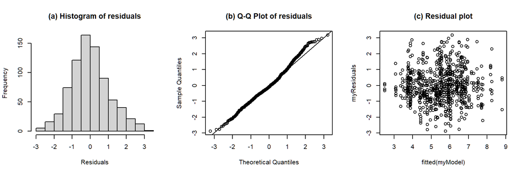

```
##
## Formula:
## f0_exc ~ foot_syls + fin_phon + (1 + foot_syls | speaker) + (1 |, nuc_str_syl) + (1 | pre_syls)
##
## Linear mixed model fit by REML. t-tests use Satterthwaite's method [
## lmerModLmerTest]
## Formula: f0_exc_equation
##    Data: nuc_data %>% filter(abs(scale(resid(nuc_f0_exc_mdl))) <= 2.5)
## Control:
## lmerControl(optimizer = "nloptwrap", optCtrl = list(algorithm = "NLOPT_LN_COBYLA",
##     maxfun = 1e+09, maxeval = 1e+07, xtol_abs = 1e-09, ftol_abs = 1e-09))
##
## REML criterion at convergence: 2397.9
##
## Scaled residuals:
##      Min       1Q   Median       3Q      Max
## -2.64763 -0.61292 -0.08904  0.62662  2.92278
##
## Random effects:
##  Groups      Name        Variance Std.Dev. Corr
##  speaker     (Intercept) 0.8129   0.9016
##              foot_syls2  0.6326   0.7953   -0.32
##              foot_syls3  0.3256   0.5706    0.26  0.54
##              foot_syls4  0.7942   0.8912    0.26  0.75  0.89
##  pre_syls    (Intercept) 0.1538   0.3921
##  nuc_str_syl (Intercept) 0.3966   0.6297
##  Residual                1.1755   1.0842
## Number of obs: 770, groups:  speaker, 11; pre_syls, 4; nuc_str_syl, 3
##
## Fixed effects:
##             Estimate Std. Error       df t value Pr(>|t|)
## (Intercept)   5.0295     0.5145   6.2545   9.776 5.10e-05 ***
## foot_syls2    0.4458     0.3052  15.8910   1.461  0.16360
## foot_syls3    1.9340     0.2342   9.9995   8.257 8.92e-06 ***
## foot_syls4    1.0522     0.3339  11.1373   3.151  0.00909 **
## fin_phonL%   -0.8058     0.2581 623.1624  -3.122  0.00188 **
## ---
## Signif. codes:  0 '***' 0.001 '**' 0.01 '*' 0.05 '.' 0.1 ' ' 1
##
## Correlation of Fixed Effects:
##            (Intr) ft_sy2 ft_sy3 ft_sy4
## foot_syls2 -0.287
## foot_syls3  0.013  0.450
## foot_syls4  0.025  0.640  0.655
## fin_phonL% -0.034  0.051 -0.037  0.006
```

ANOVA of model: f0_exc ~ foot_syls + fin_phon + (1 + foot_syls | speaker) + (1 |, nuc_str_syl) + (1 | pre_syls)

| term | sumsq | meansq | NumDF | DenDF | F value | p.value | p.adj (BH) | signif. |
| --- | --- | --- | --- | --- | --- | --- | --- | --- |
| foot_syls | 92.16 | 30.72 | 3 | 13.77 | 26.13 | < .001 | < .001 | *p* < .05 |
| fin_phon | 11.46 | 11.46 | 1 | 623.16 | 9.75 | .002 | .004 | *p* < .05 |

Omega<sup>2</sup> (partial) for f0_exc.

| Parameter | ω<sup>2</sup><sub>*p*</sub> | 95% CI |
| --- | --- | --- |
| foot_syls | .81 | [.53, .9] |
| fin_phon | .01 | [0, .04] |

Conditional and marginal R<sup>2</sup>

| marginal R<sup>2</sup> | conditional R<sup>2</sup> |
| --- | --- |
| .09 | .62 |

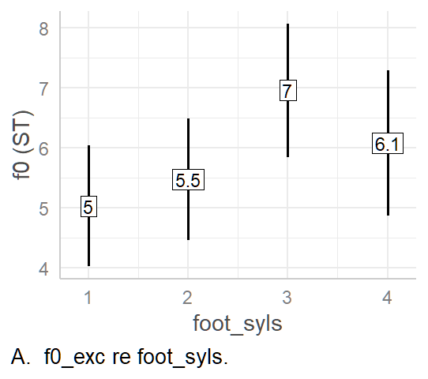

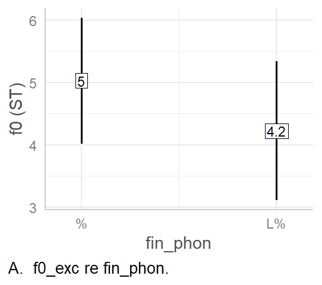

Predicted values of f0_exc

| foot_syls | predicted | conf.low | conf.high | std.error |
| --- | --- | --- | --- | --- |
| 1 | 5.03 | 4.02 | 6.04 | 0.51 |
| 2 | 5.48 | 4.46 | 6.49 | 0.52 |
| 3 | 6.96 | 5.85 | 8.08 | 0.57 |
| 4 | 6.08 | 4.86 | 7.3 | 0.62 |

Predicted values of f0_exc

| fin_phon | predicted | conf.low | conf.high | std.error |
| --- | --- | --- | --- | --- |
| % | 5.03 | 4.02 | 6.04 | 0.51 |
| L% | 4.22 | 3.11 | 5.34 | 0.57 |

f0_exc ~ foot_syls + fin_phon + (1 + foot_syls | speaker) + (1 | nuc_str_syl) + (1 | pre_syls)

b1: f0_exc ~ foot_syls + fin_phon + (1 + foot_syls | speaker) + (1 |, nuc_str_syl) + (1 | pre_syls)

| intercept | slope | estimate | conf.low | conf.high | std.error | t.value | df | p.value |
| --- | --- | --- | --- | --- | --- | --- | --- | --- |
| foot_syls1 | foot_syls2 | 0.4 | -0.2 | 1.1 | 0.31 | 1.46 | 15.89 | .164 |
| foot_syls1 | foot_syls3 | 1.9 | 1.4 | 2.5 | 0.23 | 8.26 | 10 | < .001 |
| foot_syls1 | foot_syls4 | 1.0 | 0.3 | 1.8 | 0.33 | 3.15 | 11.14 | .009 |
| foot_syls2 | foot_syls3 | 1.5 | 0.9 | 2.1 | 0.29 | 5.14 | 18.91 | < .001 |
| foot_syls2 | foot_syls4 | 0.6 | 0.0 | 1.2 | 0.27 | 2.23 | 16.62 | .04 |
| foot_syls3 | foot_syls4 | -0.9 | -1.4 | -0.3 | 0.25 | -3.49 | 14.36 | .004 |
| intercept | fin_phonL% | -0.8 | -1.3 | -0.3 | 0.26 | -3.12 | 623.09 | .002 |

#### LH Slope

Based on results from tonal target analysis, it looks like compression and truncation may be in effect. As compression leads to decrease in duration of rise (but not necessarily much decrease in excursion size), and as slope increases exponentially as duration decreases, slope has been logged here.

- model works once random intercepts of speech_rate and foot_dur removed
- model needs trimming (|sd| residuals > 3.5)

```
##
## Model found using optimx after trying original model.
```

```
##
## Model found using nloptwrap after trying after trying allFit().
```

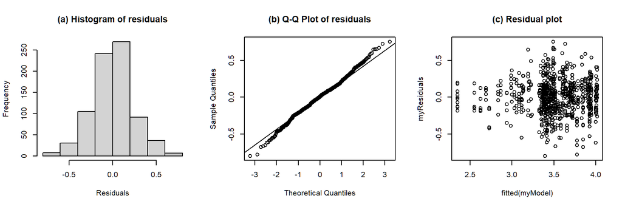

```
##
## Formula:
## log_lh_slope ~ foot_syls + fin_phon + (1 + foot_syls | speaker) +, (1 | nuc_str_syl) + (1 | pre_syls)
##
## Linear mixed model fit by REML. t-tests use Satterthwaite's method [
## lmerModLmerTest]
## Formula: lh_slope_equation
##    Data: nuc_data %>% filter(abs(scale(resid(nuc_lh_slope_mdl))) <= 3.5)
## Control: ctrl
##
## REML criterion at convergence: 75.3
##
## Scaled residuals:
##     Min      1Q  Median      3Q     Max
## -3.3507 -0.6281  0.0253  0.5825  3.1604
##
## Random effects:
##  Groups      Name        Variance Std.Dev. Corr
##  speaker     (Intercept) 0.025322 0.15913
##              foot_syls2  0.011641 0.10790  0.37
##              foot_syls3  0.031559 0.17765  0.69 0.50
##              foot_syls4  0.035135 0.18744  0.93 0.22 0.84
##  pre_syls    (Intercept) 0.026169 0.16177
##  nuc_str_syl (Intercept) 0.006102 0.07812
##  Residual                0.056507 0.23771
## Number of obs: 785, groups:  speaker, 11; pre_syls, 4; nuc_str_syl, 3
##
## Fixed effects:
##               Estimate Std. Error         df t value Pr(>|t|)
## (Intercept)   3.549649   0.108916   7.048907  32.591 5.98e-09 ***
## foot_syls2   -0.005329   0.053805  30.218024  -0.099   0.9218
## foot_syls3   -0.125219   0.063987  10.228903  -1.957   0.0782 .
## foot_syls4   -0.765983   0.071273  12.484811 -10.747 1.13e-07 ***
## fin_phonL%    0.118079   0.054745 721.696576   2.157   0.0313 *
## ---
## Signif. codes:  0 '***' 0.001 '**' 0.01 '*' 0.05 '.' 0.1 ' ' 1
##
## Correlation of Fixed Effects:
##            (Intr) ft_sy2 ft_sy3 ft_sy4
## foot_syls2 -0.106
## foot_syls3  0.183  0.388
## foot_syls4  0.233  0.328  0.661
## fin_phonL% -0.036  0.065 -0.028  0.008
```

ANOVA of model: log_lh_slope ~ foot_syls + fin_phon + (1 + foot_syls | speaker) +, (1 | nuc_str_syl) + (1 | pre_syls)

| term | sumsq | meansq | NumDF | DenDF | F value | p.value | p.adj (BH) | signif. |
| --- | --- | --- | --- | --- | --- | --- | --- | --- |
| foot_syls | 9.43 | 3.14 | 3 | 16.45 | 55.6 | < .001 | < .001 | *p* < .05 |
| fin_phon | 0.26 | 0.26 | 1 | 721.7 | 4.65 | .031 | .052 |  |

Omega<sup>2</sup> (partial) for log_lh_slope.

| Parameter | ω<sup>2</sup><sub>*p*</sub> | 95% CI |
| --- | --- | --- |
| foot_syls | .89 | [.75, .94] |
| fin_phon | .01 | [0, .02] |

Conditional and marginal R<sup>2</sup>

| marginal R<sup>2</sup> | conditional R<sup>2</sup> |
| --- | --- |
| .21 | .69 |

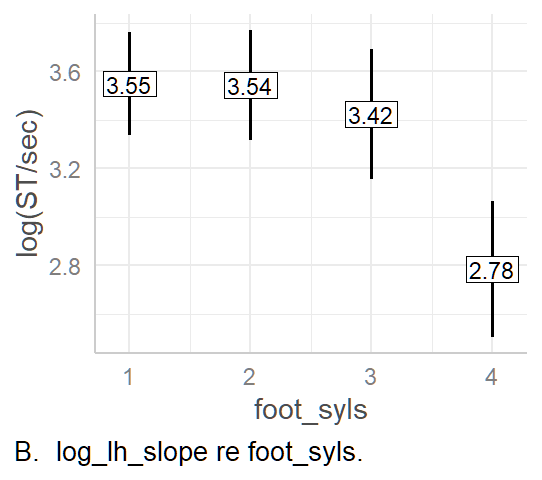

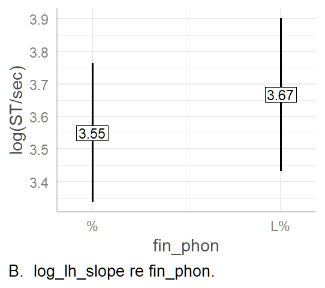

Predicted values of log_lh_slope

| foot_syls | predicted | conf.low | conf.high | std.error |
| --- | --- | --- | --- | --- |
| 1 | 3.55 | 3.34 | 3.76 | 0.11 |
| 2 | 3.54 | 3.32 | 3.77 | 0.12 |
| 3 | 3.42 | 3.16 | 3.69 | 0.14 |
| 4 | 2.78 | 2.5 | 3.07 | 0.14 |

Predicted values of log_lh_slope

| fin_phon | predicted | conf.low | conf.high | std.error |
| --- | --- | --- | --- | --- |
| % | 3.55 | 3.34 | 3.76 | 0.11 |
| L% | 3.67 | 3.43 | 3.9 | 0.12 |

log_lh_slope ~ foot_syls + fin_phon + (1 + foot_syls | speaker) + (1 | nuc_str_syl) + (1 | pre_syls)

b1: log_lh_slope ~ foot_syls + fin_phon + (1 + foot_syls | speaker) +, (1 | nuc_str_syl) + (1 | pre_syls)

| intercept | slope | estimate | conf.low | conf.high | std.error | t.value | df | p.value |
| --- | --- | --- | --- | --- | --- | --- | --- | --- |
| foot_syls1 | foot_syls2 | 0.00 | -0.12 | 0.10 | 0.05 | -0.1 | 30.22 | .922 |
| foot_syls1 | foot_syls3 | -0.12 | -0.27 | 0.02 | 0.06 | -1.96 | 10.23 | .078 |
| foot_syls1 | foot_syls4 | -0.77 | -0.92 | -0.61 | 0.07 | -10.75 | 12.48 | < .001 |
| foot_syls2 | foot_syls3 | -0.12 | -0.26 | 0.02 | 0.07 | -1.82 | 21 | .082 |
| foot_syls2 | foot_syls4 | -0.76 | -0.92 | -0.60 | 0.07 | -10.3 | 14.45 | < .001 |
| foot_syls3 | foot_syls4 | -0.64 | -0.76 | -0.52 | 0.06 | -11.43 | 15.74 | < .001 |
| intercept | fin_phonL% | 0.12 | 0.01 | 0.23 | 0.06 | 2.16 | 721.69 | .031 |

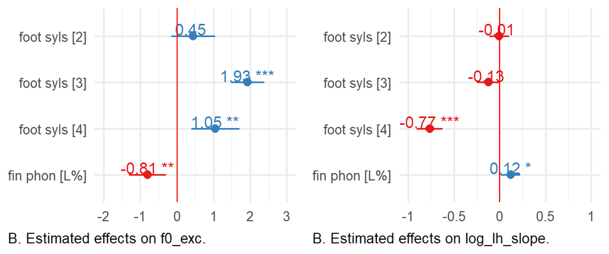

```
## Searching for good optimization settings with optimizeModel().
##   Formula:   lh_dur ~ foot_syls + fin_phon + (1 + foot_syls | speaker)
##   Optimizer: nloptwrap
##
## Model found using nloptwrap after trying original model.
```

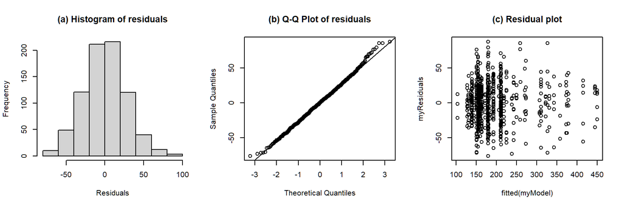

```
##
## Formula:
## lh_dur ~ foot_syls + fin_phon + (1 + foot_syls | speaker)
##
## Linear mixed model fit by REML. t-tests use Satterthwaite's method [
## lmerModLmerTest]
## Formula: lh_dur ~ foot_syls + fin_phon + (1 + foot_syls | speaker)
##    Data: nuc_data %>% filter(abs(scale(resid(lh_dur_mdl))) <= 3)
##
## REML criterion at convergence: 7519.5
##
## Scaled residuals:
##      Min       1Q   Median       3Q      Max
## -2.68949 -0.65834  0.00336  0.63608  3.09726
##
## Random effects:
##  Groups   Name        Variance Std.Dev. Corr
##  speaker  (Intercept)  710.0   26.65
##           foot_syls2   545.1   23.35    -0.52
##           foot_syls3  1458.9   38.20    -0.36  0.79
##           foot_syls4  2090.9   45.73    -0.16  0.58  0.65
##  Residual              803.2   28.34
## Number of obs: 782, groups:  speaker, 11
##
## Fixed effects:
##             Estimate Std. Error      df t value Pr(>|t|)
## (Intercept)  162.248      8.511   9.548  19.063 6.40e-09 ***
## foot_syls2    10.228      7.674   9.041   1.333    0.215
## foot_syls3    94.733     12.262   9.745   7.726 1.85e-05 ***
## foot_syls4   210.539     14.576   9.899  14.444 5.62e-08 ***
## fin_phonL%   -47.097      6.828 730.690  -6.898 1.14e-11 ***
## ---
## Signif. codes:  0 '***' 0.001 '**' 0.01 '*' 0.05 '.' 0.1 ' ' 1
##
## Correlation of Fixed Effects:
##            (Intr) ft_sy2 ft_sy3 ft_sy4
## foot_syls2 -0.569
## foot_syls3 -0.394  0.762
## foot_syls4 -0.206  0.569  0.618
## fin_phonL% -0.041  0.030 -0.020 -0.002
## optimizer (nloptwrap) convergence code: 0 (OK)
## Model failed to converge with max|grad| = 0.00253361 (tol = 0.002, component 1)
```

ANOVA of model: lh_dur ~ foot_syls + fin_phon + (1 + foot_syls | speaker)

| term | sumsq | meansq | NumDF | DenDF | F value | p.value | p.adj (BH) | signif. |
| --- | --- | --- | --- | --- | --- | --- | --- | --- |
| foot_syls | 243388 | 81129 | 3 | 9.72 | 101.01 | < .001 | < .001 | *p* < .05 |
| fin_phon | 38218 | 38218 | 1 | 730.69 | 47.58 | < .001 | < .001 | *p* < .05 |

Omega<sup>2</sup> (partial) for Dependent variable.

| Parameter | ω<sup>2</sup><sub>*p*</sub> | 95% CI |
| --- | --- | --- |
| foot_syls | .96 | [.86, .98] |
| fin_phon | .06 | [.03, .1] |

Predicted values of lh_dur

| foot_syls | predicted | conf.low | conf.high | std.error |
| --- | --- | --- | --- | --- |
| 1 | 162.25 | 145.54 | 178.96 | 8.51 |
| 2 | 172.48 | 157.65 | 187.3 | 7.55 |
| 3 | 256.98 | 233.7 | 280.26 | 11.86 |
| 4 | 372.79 | 342.76 | 402.81 | 15.29 |

Predicted values of lh_dur

| fin_phon | predicted | conf.low | conf.high | std.error |
| --- | --- | --- | --- | --- |
| % | 162.25 | 145.54 | 178.96 | 8.51 |
| L% | 115.15 | 94.16 | 136.14 | 10.69 |

### Additional model

#### H time proportional to duration of foot

```
## Searching for good optimization settings with optimizeModel().
##   Formula:   `h_t as ratio of foot` ~ foot_syls + (1 | speaker) + (1 | gender) +, (1 | pre_syls) + (1 | nuc_new_word) + (1 | nuc_str_syl) +, (1 | fin_phon)
##   Optimizer: optimx
##
## Model found using optimx after trying original model.
```

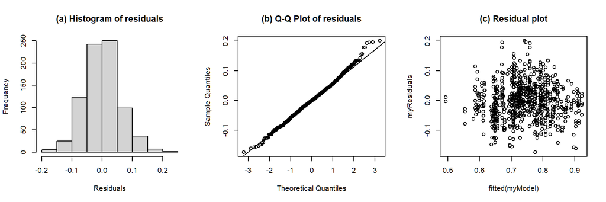

```
##
## Formula:
## `h_t as ratio of foot` ~ foot_syls + (1 | speaker) + (1 | gender) +, (1 | pre_syls) + (1 | nuc_new_word) + (1 | nuc_str_syl) +, (1 | fin_phon)
##
## Linear mixed model fit by REML. t-tests use Satterthwaite's method [
## lmerModLmerTest]
## Formula: h_t_re_ft_dur_equation
##    Data: nuc_data
## Control:
## lmerControl(optimizer = optimizer, calc.derivs = F, optCtrl = list(method = "nlminb",
##     starttests = F, kkt = F))
##
## REML criterion at convergence: -2094.7
##
## Scaled residuals:
##     Min      1Q  Median      3Q     Max
## -2.8713 -0.6488 -0.0029  0.6316  3.3229
##
## Random effects:
##  Groups       Name        Variance  Std.Dev.
##  speaker      (Intercept) 2.676e-03 0.051728
##  pre_syls     (Intercept) 8.927e-04 0.029879
##  nuc_str_syl  (Intercept) 1.830e-03 0.042776
##  fin_phon     (Intercept) 1.962e-03 0.044291
##  nuc_new_word (Intercept) 1.341e-05 0.003662
##  gender       (Intercept) 9.272e-04 0.030450
##  Residual                 3.648e-03 0.060399
## Number of obs: 788, groups:
## speaker, 11; pre_syls, 4; nuc_str_syl, 3; fin_phon, 2; nuc_new_word, 2; gender, 2
##
## Fixed effects:
##               Estimate Std. Error         df t value Pr(>|t|)
## (Intercept)   0.841044   0.051296   3.868824  16.396 0.000102 ***
## foot_syls2   -0.140159   0.010685 369.151668 -13.118  < 2e-16 ***
## foot_syls3   -0.120633   0.008744 768.070637 -13.797  < 2e-16 ***
## foot_syls4    0.008050   0.011848   6.949802   0.679 0.518851
## ---
## Signif. codes:  0 '***' 0.001 '**' 0.01 '*' 0.05 '.' 0.1 ' ' 1
##
## Correlation of Fixed Effects:
##            (Intr) ft_sy2 ft_sy3
## foot_syls2 -0.130
## foot_syls3 -0.079  0.331
## foot_syls4 -0.093  0.425  0.299
```

ANOVA of model: `h_t as ratio of foot` ~ foot_syls + (1 | speaker) + (1 | gender) +, (1 | pre_syls) + (1 | nuc_new_word) + (1 | nuc_str_syl) +, (1 | fin_phon)

| term | sumsq | meansq | NumDF | DenDF | F value | p.value | p.adj (BH) | signif. |
| --- | --- | --- | --- | --- | --- | --- | --- | --- |
| foot_syls | 1.28 | 0.43 | 3 | 19.06 | 117.37 | < .001 | < .001 | *p* < .05 |

Omega<sup>2</sup> (partial) for h_t as ratio of foot.

| Parameter | ω<sup>2</sup><sub>*p*</sub> | 95% CI |
| --- | --- | --- |
| foot_syls | .94 | [.87, .96] |

Conditional and marginal R<sup>2</sup>

| marginal R<sup>2</sup> | conditional R<sup>2</sup> |
| --- | --- |
| .21 | .76 |

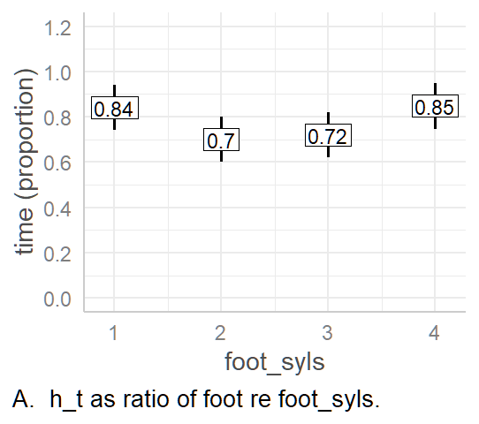

Predicted values of h_t as ratio of foot

| foot_syls | predicted | conf.low | conf.high | std.error |
| --- | --- | --- | --- | --- |
| 1 | 0.84 | 0.74 | 0.94 | 0.05 |
| 2 | 0.7 | 0.6 | 0.8 | 0.05 |
| 3 | 0.72 | 0.62 | 0.82 | 0.05 |
| 4 | 0.85 | 0.75 | 0.95 | 0.05 |

`h_t as ratio of foot` ~ foot_syls + (1 | speaker) + (1 | gender) + (1 | pre_syls) + (1 | nuc_new_word) + (1 | nuc_str_syl) + (1 | fin_phon)

b1: h_t as ratio of foot ~ foot_syls + (1 | speaker) + (1 | gender) +, (1 | pre_syls) + (1 | nuc_new_word) + (1 | nuc_str_syl) +, (1 | fin_phon)

| intercept | slope | estimate | conf.low | conf.high | std.error | t.value | df | p.value |
| --- | --- | --- | --- | --- | --- | --- | --- | --- |
| foot_syls1 | foot_syls2 | -0.14 | -0.16 | -0.12 | 0.01 | -13.12 | 369.15 | < .001 |
| foot_syls1 | foot_syls3 | -0.12 | -0.14 | -0.10 | 0.01 | -13.8 | 768.07 | < .001 |
| foot_syls1 | foot_syls4 | 0.01 | -0.02 | 0.04 | 0.01 | 0.68 | 6.95 | .519 |
| foot_syls2 | foot_syls3 | 0.02 | 0.00 | 0.04 | 0.01 | 1.72 | 368.82 | .086 |
| foot_syls2 | foot_syls4 | 0.15 | 0.12 | 0.18 | 0.01 | 12.23 | 9.14 | < .001 |
| foot_syls3 | foot_syls4 | 0.13 | 0.10 | 0.16 | 0.01 | 10.34 | 8.47 | < .001 |

#### H time proportional to duration of voicing

```
## Searching for good optimization settings with optimizeModel().
##   Formula:   `h_t as ratio of voicing` ~ foot_syls + (1 | speaker) + (1 |, gender) + (1 | pre_syls) + (1 | nuc_new_word) + (1 | nuc_str_syl) +, (1 | fin_phon)
##   Optimizer: optimx
##
## Model found using optimx after trying original model.
```

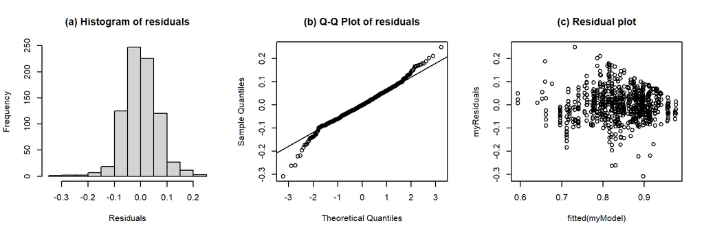

```
##
## Running step() ...
## Model found: `h_t as ratio of voicing` ~ foot_syls + (1 | speaker) + (1 |, gender) + (1 | nuc_new_word) + (1 | nuc_str_syl) + (1 | fin_phon)
```

```
## Searching for good optimization settings with optimizeModel().
##   Formula:   `h_t as ratio of voicing` ~ foot_syls + (1 | speaker) + (1 |, gender) + (1 | pre_syls) + (1 | nuc_new_word) + (1 | nuc_str_syl) +, (1 | fin_phon)
##   Optimizer: optimx
##
## Model found using optimx after trying original model.
```

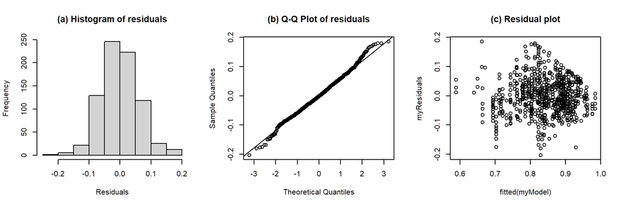

```
##
## Formula:
## `h_t as ratio of voicing` ~ foot_syls + (1 | speaker) + (1 |, gender) + (1 | pre_syls) + (1 | nuc_new_word) + (1 | nuc_str_syl) +, (1 | fin_phon)
##
## Linear mixed model fit by REML. t-tests use Satterthwaite's method [
## lmerModLmerTest]
## Formula: nuc_h_t_re_v_dur_equation
##    Data: nuc_nuc_h_t_re_v_dur.trimmed
## Control:
## lmerControl(optimizer = optimizer, calc.derivs = F, optCtrl = list(method = "nlminb",
##     starttests = F, kkt = F))
##
## REML criterion at convergence: -2053.8
##
## Scaled residuals:
##     Min      1Q  Median      3Q     Max
## -3.3050 -0.6513 -0.0300  0.6474  3.0147
##
## Random effects:
##  Groups       Name        Variance  Std.Dev.
##  speaker      (Intercept) 1.945e-03 0.044105
##  pre_syls     (Intercept) 6.732e-05 0.008205
##  nuc_str_syl  (Intercept) 1.817e-03 0.042631
##  fin_phon     (Intercept) 6.676e-03 0.081706
##  nuc_new_word (Intercept) 2.851e-04 0.016885
##  gender       (Intercept) 2.471e-03 0.049705
##  Residual                 3.765e-03 0.061357
## Number of obs: 780, groups:
## speaker, 11; pre_syls, 4; nuc_str_syl, 3; fin_phon, 2; nuc_new_word, 2; gender, 2
##
## Fixed effects:
##               Estimate Std. Error         df t value Pr(>|t|)
## (Intercept)  7.548e-01  7.509e-02  2.323e+00  10.051  0.00577 **
## foot_syls2   2.398e-02  9.097e-03  1.649e+01   2.636  0.01766 *
## foot_syls3  -7.502e-03  8.866e-03  7.624e+02  -0.846  0.39771
## foot_syls4  -4.331e-04  1.349e-02  1.487e+02  -0.032  0.97443
## ---
## Signif. codes:  0 '***' 0.001 '**' 0.01 '*' 0.05 '.' 0.1 ' ' 1
##
## Correlation of Fixed Effects:
##            (Intr) ft_sy2 ft_sy3
## foot_syls2 -0.097
## foot_syls3 -0.056  0.423
## foot_syls4 -0.084  0.485  0.276
```

ANOVA of model: `h_t as ratio of voicing` ~ foot_syls + (1 | speaker) + (1 |, gender) + (1 | pre_syls) + (1 | nuc_new_word) + (1 | nuc_str_syl) +, (1 | fin_phon)

| term | sumsq | meansq | NumDF | DenDF | F value | p.value | p.adj (BH) | signif. |
| --- | --- | --- | --- | --- | --- | --- | --- | --- |
| foot_syls | 0.05 | 0.02 | 3 | 15.38 | 4.45 | .019 | .034 | *p* < .05 |

Omega<sup>2</sup> (partial) for h_t as ratio of voicing.

| Parameter | ω<sup>2</sup><sub>*p*</sub> | 95% CI |
| --- | --- | --- |
| foot_syls | .35 | [0, .6] |

Conditional and marginal R<sup>2</sup>

| marginal R<sup>2</sup> | conditional R<sup>2</sup> |
| --- | --- |
| .01 | .78 |

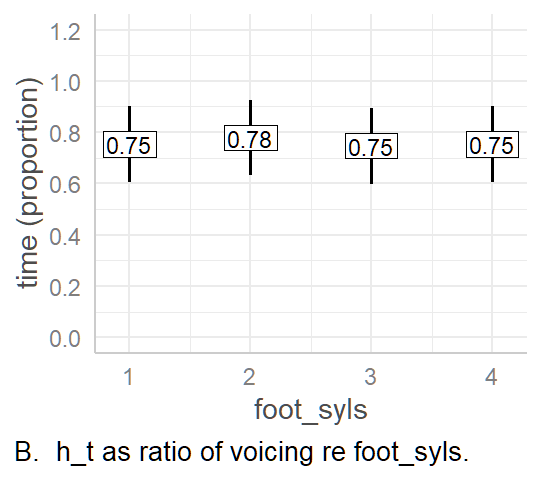

Predicted values of h_t as ratio of voicing

| foot_syls | predicted | conf.low | conf.high | std.error |
| --- | --- | --- | --- | --- |
| 1 | 0.75 | 0.61 | 0.9 | 0.08 |
| 2 | 0.78 | 0.63 | 0.93 | 0.07 |
| 3 | 0.75 | 0.6 | 0.89 | 0.08 |
| 4 | 0.75 | 0.61 | 0.9 | 0.08 |

`h_t as ratio of voicing` ~ foot_syls + (1 | speaker) + (1 | gender) + (1 | pre_syls) + (1 | nuc_new_word) + (1 | nuc_str_syl) + (1 | fin_phon)

b1: h_t as ratio of voicing ~ foot_syls + (1 | speaker) + (1 |, gender) + (1 | pre_syls) + (1 | nuc_new_word) + (1 | nuc_str_syl) +, (1 | fin_phon)

| intercept | slope | estimate | conf.low | conf.high | std.error | t.value | df | p.value |
| --- | --- | --- | --- | --- | --- | --- | --- | --- |
| foot_syls1 | foot_syls2 | 0.02 | 0.00 | 0.04 | 0.01 | 2.64 | 16.49 | .018 |
| foot_syls1 | foot_syls3 | -0.01 | -0.03 | 0.01 | 0.01 | -0.85 | 762.4 | .398 |
| foot_syls1 | foot_syls4 | 0.00 | -0.03 | 0.03 | 0.01 | -0.03 | 148.66 | .974 |
| foot_syls2 | foot_syls3 | -0.03 | -0.05 | -0.01 | 0.01 | -3.26 | 15.94 | .005 |
| foot_syls2 | foot_syls4 | -0.02 | -0.05 | 0.00 | 0.01 | -2.02 | 19.42 | .057 |
| foot_syls3 | foot_syls4 | 0.01 | -0.02 | 0.04 | 0.01 | 0.51 | 126.43 | .613 |